# Practica final Aprendizaje Computacional

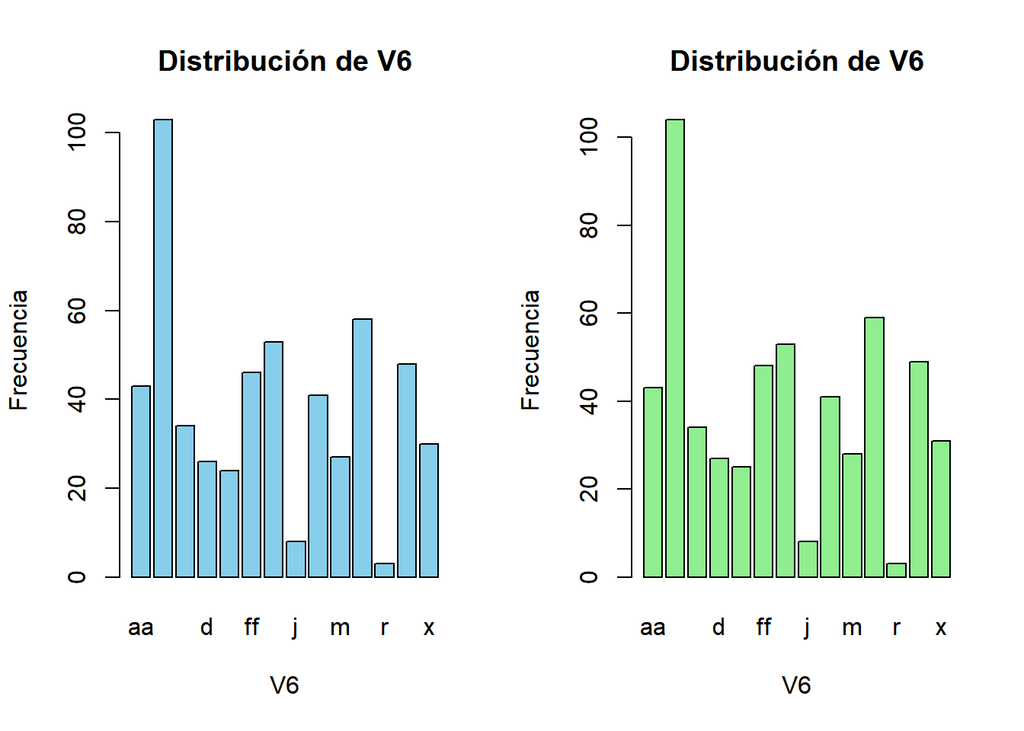

```r
#____________________V6_______________
frecuencias <- table(credit.Datos.Train$V6)
barplot(frecuencias,
        main = "Distribución de V6",
        xlab = "V6",
        ylab = "Frecuencia",
        col = "skyblue")

frecuencias <- table(credit.Datos.Train.imp$V6)
barplot(frecuencias,
        main = "Distribución de V6",
        xlab = "V6",
        ylab = "Frecuencia",
        col = "lightgreen")
```

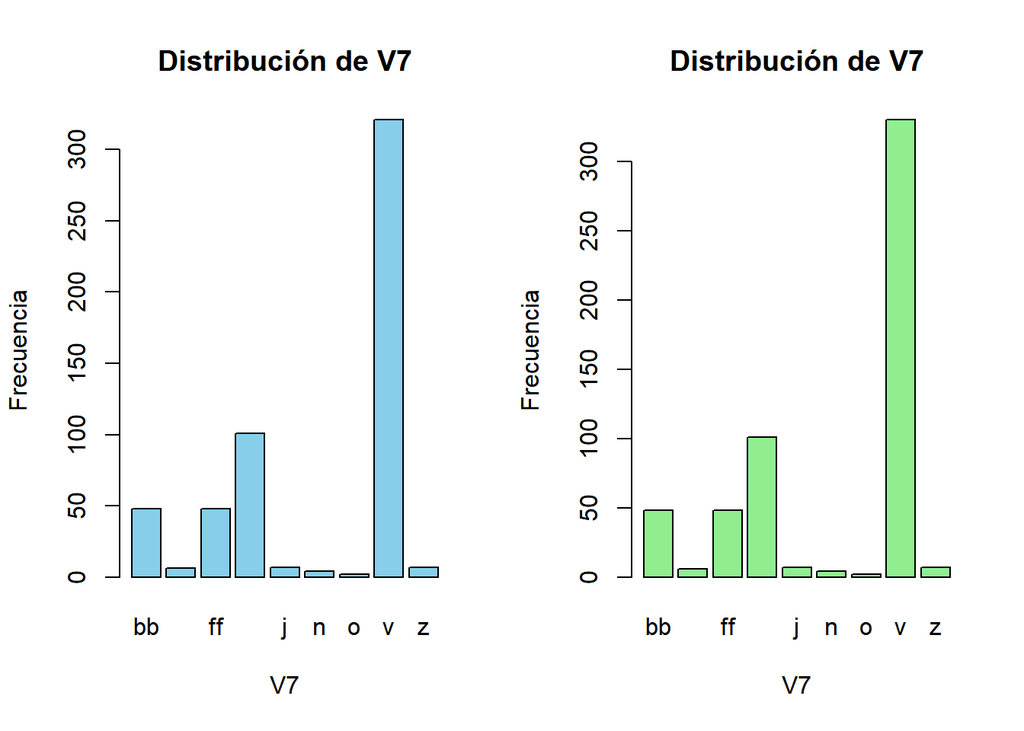

```r
#____________________V7_______________
frecuencias <- table(credit.Datos.Train$V7)
barplot(frecuencias,
        main = "Distribución de V7",
        xlab = "V7",
        ylab = "Frecuencia",
        col = "skyblue")

frecuencias <- table(credit.Datos.Train.imp$V7)
barplot(frecuencias,
        main = "Distribución de V7",
        xlab = "V7",
        ylab = "Frecuencia",
        col = "lightgreen")
```

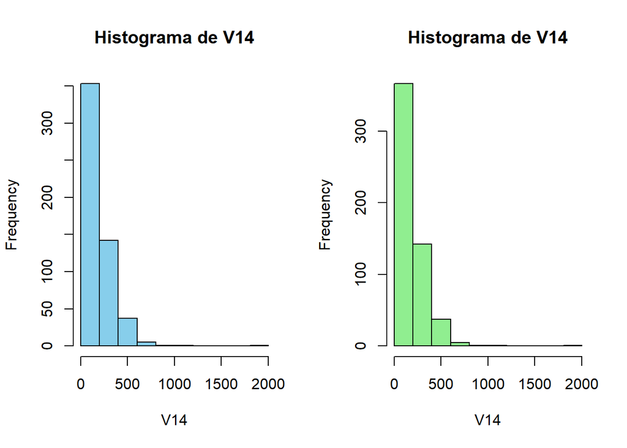

```r
#____________________V14_______________
hist(credit.Datos.Train$V14,
     main = "Histograma de V14",
     xlab = "V14",
     col = "skyblue")

hist(credit.Datos.Train.imp$V14,
     main = "Histograma de V14",
     xlab = "V14",
     col = "lightgreen")
```

Como es evidente no ha cambiado casi nada (inapreciable). Entre otras cosas, debido al bajo número de NA.

En cuanto a la sustitución mediante estudio de correlaciones, podemos ver si hay alguna de la siguiente manera (lo hacemos con los datos sin imputar para justificar que no era necesario usarlo):

```r
# Solo las columnas numéricas
credit.Datos.numericas <- credit.Datos.Train[, sapply(credit.Datos.Train, is.numeric)]

matriz_correlacion <- cor(credit.Datos.numericas, use = "complete.obs")

print(matriz_correlacion)
```

```
##                        Edad      Deuda AnyosContratado  Solvencia         V14
## Edad             1.00000000  0.2285522      0.33280076  0.1778291 -0.08941137
## Deuda            0.22855222  1.0000000      0.24493606  0.2171899 -0.23748347
## AnyosContratado  0.33280076  0.2449361      1.00000000  0.3246872 -0.02287527
## Solvencia        0.17782905  0.2171899      0.32468718  1.0000000 -0.11703347
## V14             -0.08941137 -0.2374835     -0.02287527 -0.1170335  1.00000000
## V15              0.11198221  0.1462029      0.17696894  0.3934957 -0.06038619
##                         V15
## Edad             0.11198221
## Deuda            0.14620294
## AnyosContratado  0.17696894
## Solvencia        0.39349573
## V14             -0.06038619
## V15              1.00000000
```

Es evidente que no hay ninguna fuerte correlación entre variables, por tanto, hemos excluido esta opción de imputación. Al no haber correlación tampoco es interesante la sustitución de variables numéricas mediante clustering (knn).

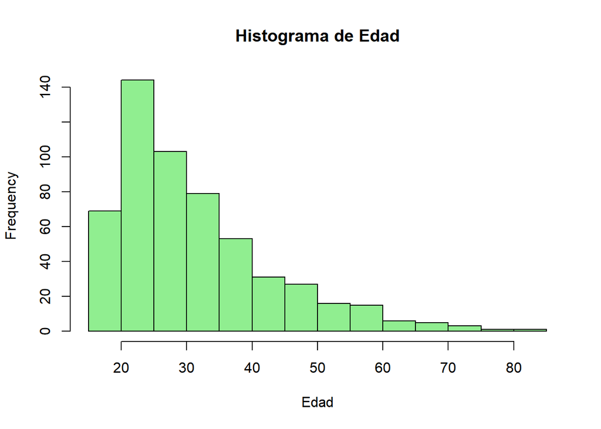

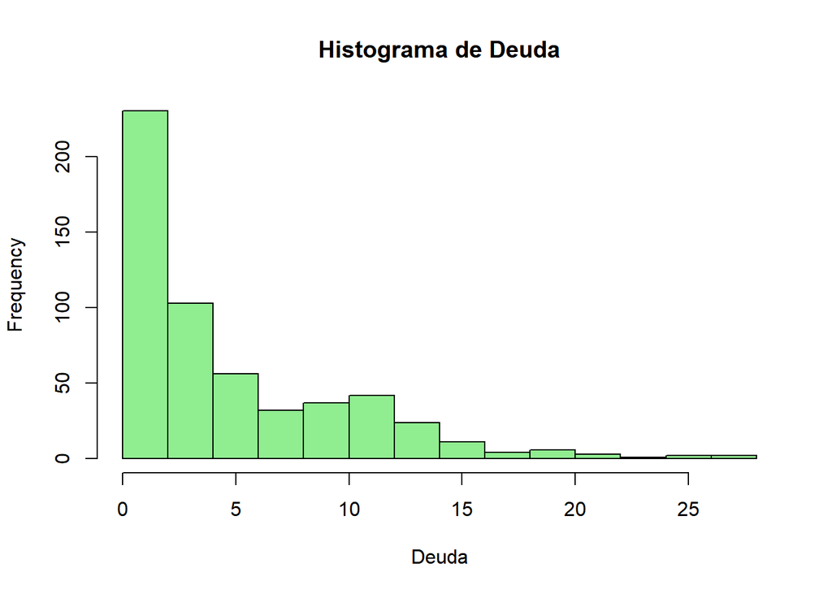

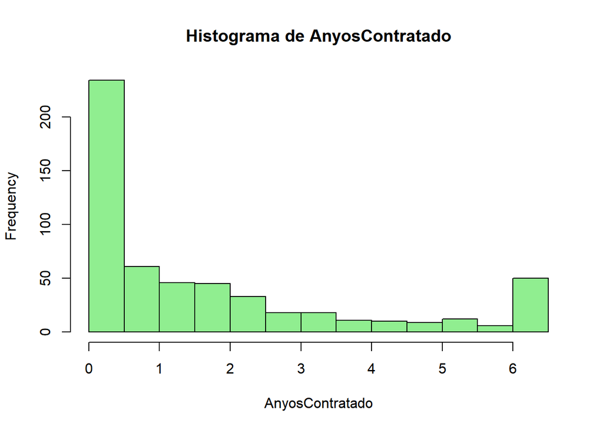

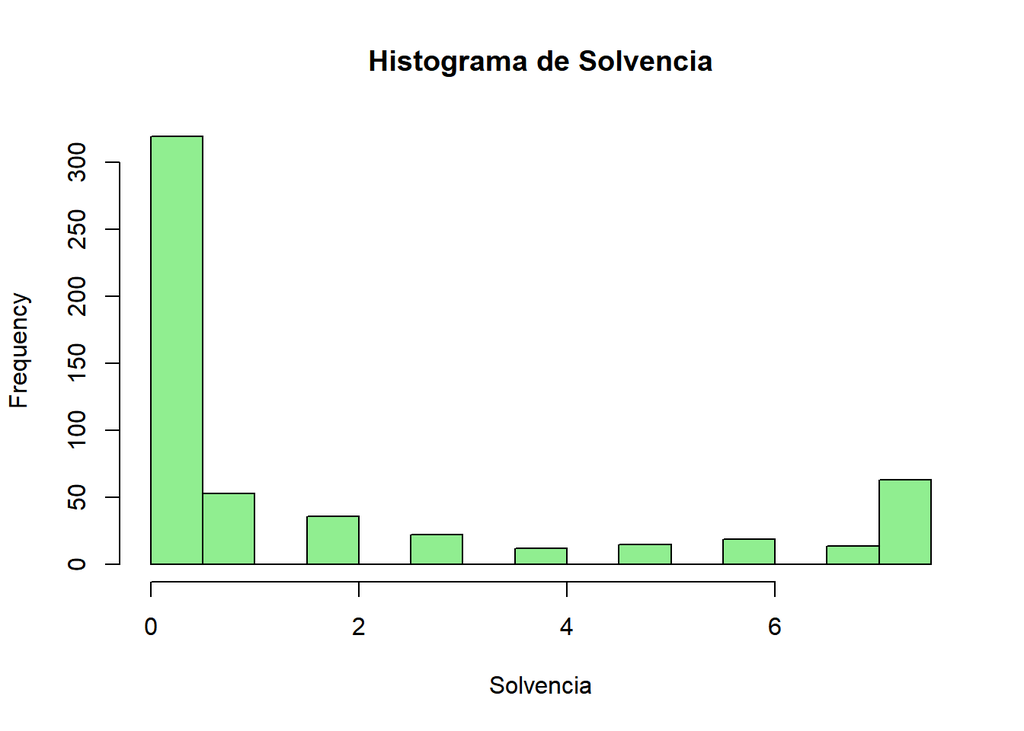

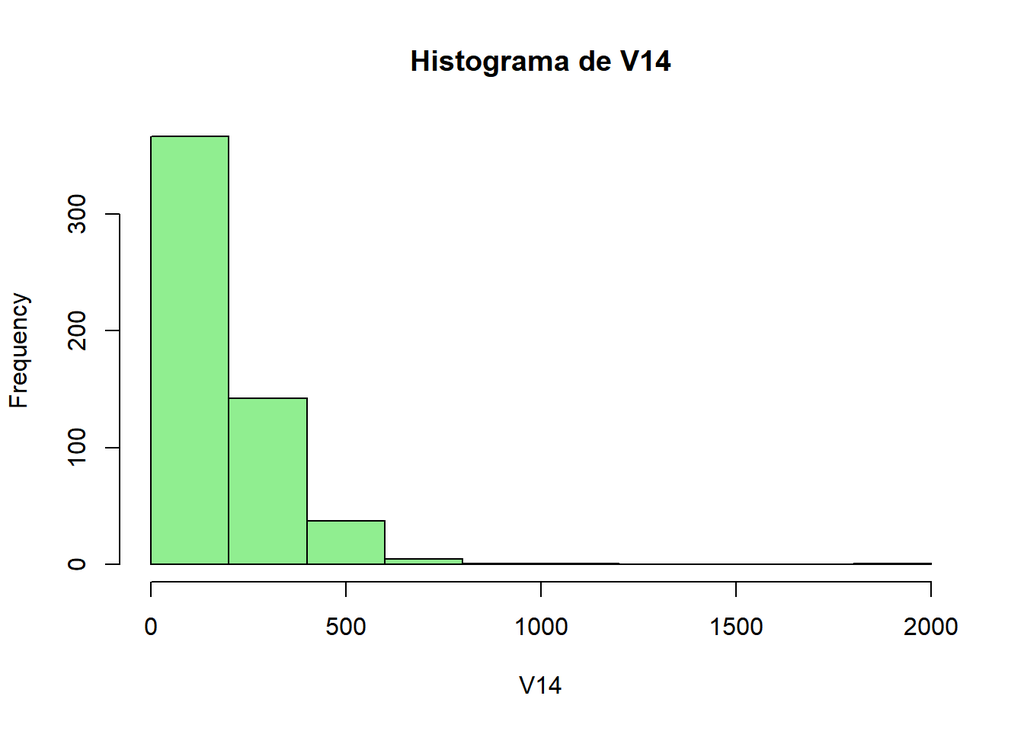

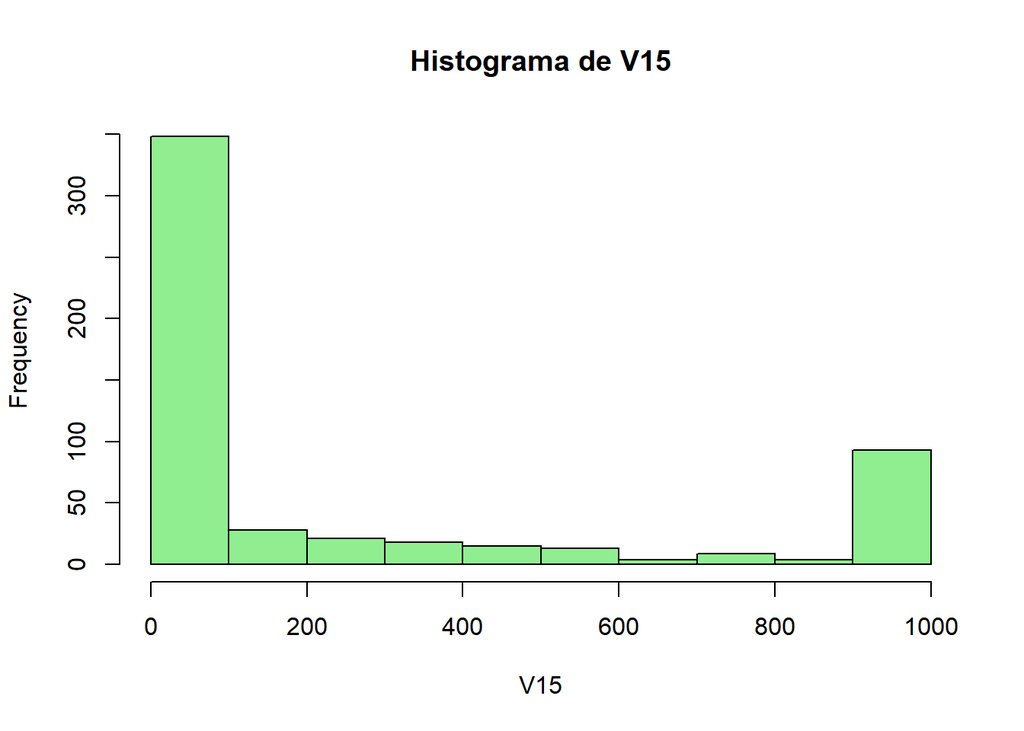

```r
gen_plots <- function() {

  credit.Datos.continuas <- credit.Datos.Train.imp[, sapply(credit.Datos.Train.imp, is.numeric)]

  for (name in colnames(credit.Datos.continuas)) {
    hist(credit.Datos.continuas[[name]],
         main = paste("Histograma de", name),
         xlab = name,
         col = "lightgreen")
  }
}

# Ejecutar la función
gen_plots()
```

En el caso en el que queramos quitar toda la imputación, comentar este código:

```r
credit.Datos.Test <- credit.Datos.Test.imp
credit.Datos.Train <- credit.Datos.Train.imp
```

# 5 Pre-procesado de datos (II): Eliminar predictores correlados o de poca Varianza

## 5.1 Eliminar variables con poca Varianza

Debemos de comprobar si la base de datos tiene columnas con poca varianza. Esto lo podemos comprobar con nearZero():

**Aclaración:** No tenemos en cuenta la última columna con valores {train, test} ya que no cuentan para el análisis.

```r
nearZeroVar(credit.Datos.Train[, 1:16])
```

```
## integer(0)
```

```r
nearZeroVar(credit.Datos.Test[, 1:16])
```

```
## integer(0)
```

Como vemos no hay ninguna columna que tenga varianza cercana a cero, lo que nos indica que los datos están ya bastante “limpios”.

Quitamos la última columna

```r
credit.Datos.Train$Origen <- NULL
credit.Datos.Test$Origen <- NULL
```

# 6 Entrenamiento de modelos que proporciona Caret

## 6.1 **GBM**

Lo primero que debemos de buscar son las características de este modelo para ver si es interesante para nuestro caso. En este enlace podemos encontrar mucha información acerca del mismo:  
https://www.linkedin.com/pulse/ai-algorithms-deep-dive-gradient-boosting-machines-gbm-vasu-rao-snesc

En dicho enlace, en el apartado “Applications of GBM in Enterprises”, recomienda usarlo para “Credit Scoring”:

- **Credit Scoring:** Financial institutions use GBM to predict the creditworthiness of loan applicants, enabling informed lending decisions and minimizing risk.

También contamos con información sobre sus debilidades, y es importante tenerlas en cuenta:

While GBM is a powerful tool, it’s not without its limitations:

- **Computational Intensity:** Training GBM models can be computationally expensive, especially when dealing with large datasets and many boosting stages (iterations).
- **Risk of Overfitting:** Without proper tuning and regularization techniques, GBM models can overfit, particularly on noisy data. Overfitting occurs when the model performs well on the training data but poorly on unseen data.
- **Parameter Sensitivity:** The performance of GBM models is highly dependent on the chosen hyperparameters. Careful tuning is necessary to achieve optimal results.

Por lo tanto, puede ser una buena opción. Una vez hemos investigado sobre su funcionamiento, es importante ver con qué requisitos de preprocesado gbm se encuentra más cómodo. En el enlace anterior recomiendan:

1. **Data Preprocessing:** Clean your data to ensure optimal GBM performance. This includes handling missing values, normalizing numerical features, and encoding categorical variables.

Hacemos una copia de la base de datos para no sobrescribirla.

```r
credit.Datos.gbm.Train <- credit.Datos.Train
credit.Datos.gbm.Test <- credit.Datos.Test
```

Nota: Para poder hacer muchas pruebas y automatizar todo el proceso de configuraciones de preprocesado hemos ideado una automatización (comprobada experimentalmente) que te permite probar todas las configuraciones existentes, entrenar con cada una de ellas y seleccionar la “mejor” en cuanto al intervalo de confianza de cada una de las configuraciones. A continuación le mostramos como se hace:

Para empezar vamos a mencionar cada una de los elementos de preprocesado que van a estar presentes en las configuraciones, y por qué lo hacemos:

1. **Dummy:** Preprocesado prometedor. Siguiendo las recomendaciones del enlace anterior, se recomienda encarecidamente hacer dummy.
2. **PCA:** Pese a no indicar en ningún sitio que PCA/ICA sea necesario en gbm, debemos de comprobarlo experimentalmente. Por lo tanto, lo incluimos en nuestro preprocesado.
3. **ICA:** Igual que PCA.
4. **Normalización Range:** En la web anterior recomiendan normalizar los datos antes del entrenamiento, sin embargo, como sabemos gbm está basado en árboles de decisión, y la normalización no les afecta mucho. Como podemos encontrar en: https://datascience.stackexchange.com/questions/6721/how-to-preprocess-different-kinds-of-data-continuous-discrete-categorical-be

   *“In fact, the results should be consistent regardless of any scaling or translational normalization, since the trees can choose equivalent splitting points”*

   Por lo tanto, ante esta contradicción, la única forma de comprobarlo es realizando los dos tipos de normalización que encontramos en el documento de caret y viendo resultados.
5. **Normalización Center-Scale:** Igual que Range.

Nota: En PCA, debido a la opción fullRank=TRUE, se está eliminando una categoría de cada variable categórica después de crear las dummies.

### 6.1.1 Declaración de funciones necesarias para configuraciones:

#### 6.1.1.1 Dummy

```r
dummy <- function(train, test) {
  credit.Datos.gbm.dummy.Train <- get(train, envir = .GlobalEnv)
  credit.Datos.gbm.dummy.Test <- get(test, envir = .GlobalEnv)

  #DUMMY
  # Definir la variable de salida y las variables de entrada
  credit.Var.Salida.Usada <- "V16"
  credit.Vars.Entrada.Usadas <- setdiff(names(credit.Datos.gbm.dummy.Train), credit.Var.Salida.Usada)

  # Convertir la variable de salida a factor (para clasificación)
  credit.Datos.gbm.dummy.Train[[credit.Var.Salida.Usada]] <- as.factor(credit.Datos.gbm.dummy.Train[[credit.Var.Salida.Usada]])
  credit.Datos.gbm.dummy.Test[[credit.Var.Salida.Usada]] <- as.factor(credit.Datos.gbm.dummy.Test[[credit.Var.Salida.Usada]])

  # Crear el modelo dummy solo para las variables de entrada
  dummy_model <- dummyVars(~ ., data = credit.Datos.gbm.dummy.Train[, credit.Vars.Entrada.Usadas], fullRank = TRUE)

  # Transformar las variables de entrada a dummies (sin tocar la salida)
  credit.Datos.Train.Dummies <- data.frame(predict(dummy_model, credit.Datos.gbm.dummy.Train[, credit.Vars.Entrada.Usadas]))
  credit.Datos.Test.Dummies <- data.frame(predict(dummy_model, credit.Datos.gbm.dummy.Test[, credit.Vars.Entrada.Usadas]))

  # Añadir la variable de salida de nuevo a los conjuntos transformados
  credit.Datos.Train.Dummies[[credit.Var.Salida.Usada]] <- credit.Datos.gbm.dummy.Train[[credit.Var.Salida.Usada]]
  credit.Datos.Test.Dummies[[credit.Var.Salida.Usada]] <- credit.Datos.gbm.dummy.Test[[credit.Var.Salida.Usada]]

  assign(train, credit.Datos.Train.Dummies, envir = .GlobalEnv)
  assign(test, credit.Datos.Test.Dummies, envir = .GlobalEnv)
}
```

#### 6.1.1.2 PCA

```r
pca <- function(train, test) {
  credit.Datos.gbm.pca.Train <- get(train, envir = .GlobalEnv)
  credit.Datos.gbm.pca.Test <- get(test, envir = .GlobalEnv)

  # PCA
  credit.PreProc.Pca.Mod <- preProcess(credit.Datos.gbm.pca.Train, method = "pca", thresh = 0.95)  # 95% de la varianza explicada
  print(credit.PreProc.Pca.Mod)
  credit.Datos.Train.Pca <- predict(credit.PreProc.Pca.Mod, credit.Datos.gbm.pca.Train)
  credit.Datos.Test.Pca <- predict(credit.PreProc.Pca.Mod, credit.Datos.gbm.pca.Test)

  assign(train, credit.Datos.Train.Pca, envir = .GlobalEnv)
  assign(test, credit.Datos.Test.Pca, envir = .GlobalEnv)
}
```

#### 6.1.1.3 ICA

```r
ica <- function(train, test) {
  credit.Datos.gbm.ica.Train <- get(train, envir = .GlobalEnv)
  credit.Datos.gbm.ica.Test <- get(test, envir = .GlobalEnv)

  # ICA
  credit.PreProc.Ica.Mod <- preProcess(credit.Datos.gbm.ica.Train, method = "ica", n.comp = 10)  # 10 componentes independientes
  credit.PreProc.Ica.Mod
  credit.Datos.Train.Ica <- predict(credit.PreProc.Ica.Mod, credit.Datos.gbm.ica.Train)
  credit.Datos.Test.Ica <- predict(credit.PreProc.Ica.Mod, credit.Datos.gbm.ica.Test)

  assign(train, credit.Datos.Train.Ica, envir = .GlobalEnv)
  assign(test, credit.Datos.Test.Ica, envir = .GlobalEnv)
}
```

#### 6.1.1.4 Normalización range

```r
norm_range <- function(train, test) {
  credit.Datos.gbm.norm.range.Train <- get(train, envir = .GlobalEnv)
  credit.Datos.gbm.norm.range.Test <- get(test, envir = .GlobalEnv)

  # Normalización range
  # Identificar las variables numéricas del conjunto de entrenamiento
  numeric_vars <- names(credit.Datos.gbm.norm.range.Train)[sapply(credit.Datos.gbm.norm.range.Train, is.numeric)]

  # Ajustar el modelo de preprocesamiento en el entrenamiento (normalización Min-Max)
  # "range" realiza una normalización entre 0 y 1
  preProcParams <- preProcess(credit.Datos.gbm.norm.range.Train[, numeric_vars], method = c("range"))

  # Aplicar la normalización al conjunto de entrenamiento
  credit.Datos.Train.norm <- predict(preProcParams, credit.Datos.gbm.norm.range.Train)

  # Aplicar la misma transformación al conjunto de test
  credit.Datos.Test.norm <- predict(preProcParams, credit.Datos.gbm.norm.range.Test)

  assign(train, credit.Datos.Train.norm, envir = .GlobalEnv)
  assign(test, credit.Datos.Test.norm, envir = .GlobalEnv)
}
```

#### 6.1.1.5 Normalización Center-Scale

```r
norm_center_scale <- function(train, test) {
  credit.Datos.gbm.norm.cs.Train <- get(train, envir = .GlobalEnv)
  credit.Datos.gbm.norm.cs.Test <- get(test, envir = .GlobalEnv)

  # Normalización center-scale
  credit.Var.Salida.Usada <- c("V16")
  credit.Var.Entrada.Usadas <- setdiff(names(credit.Datos.gbm.norm.cs.Train),credit.Var.Salida.Usada)

  credit.preProc.CS.Mod<-preProcess(credit.Datos.gbm.norm.cs.Train[credit.Var.Entrada.Usadas],
                                    method=c("center","scale"))
  credit.Datos.Train.CS <- predict(credit.preProc.CS.Mod,credit.Datos.gbm.norm.cs.Train)
  credit.Datos.Test.CS <- predict(credit.preProc.CS.Mod,credit.Datos.gbm.norm.cs.Test)

  assign(train, credit.Datos.Train.CS, envir = .GlobalEnv)
  assign(test, credit.Datos.Test.CS, envir = .GlobalEnv)
}
```

### 6.1.2 Configuración

```r
configuracion <- list(
  conf1  = list("dummy"),
  conf2  = list("pca"),
  conf3  = list("ica"),
  conf4  = list("norm_range"),
  conf5  = list("norm_center_scale"),

  # Combinaciones de Dummy
  conf6  = list("dummy", "pca"),
  conf7  = list("dummy", "ica"),
  conf8  = list("dummy", "norm_range"),
  conf9  = list("dummy", "norm_center_scale"),

  # Combinaciones con PCA
  conf10 = list("pca", "norm_range"),
  conf11 = list("pca", "norm_center_scale"),

  # Combinaciones con ICA
  conf12 = list("ica", "norm_range"),
  conf13 = list("ica", "norm_center_scale"),

  # Combinaciones triples
  conf14 = list("dummy", "pca", "norm_range"),
  conf15 = list("dummy", "pca", "norm_center_scale"),
  conf16 = list("dummy", "ica", "norm_range"),
  conf17 = list("dummy", "ica", "norm_center_scale"),

  # Combinaciones Cuádruples
  conf18 = list("dummy", "pca", "norm_range", "ica"),
  conf19 = list("dummy", "ica", "norm_center_scale", "norm_range")
)
```

### 6.1.3 Eliminar variables con varianza cercana a cero

```r
eliminar_varianza_cero <- function(train_data, test_data) {

  # Detectar columnas con varianza cero
  cols_varianza_cero <- nearZeroVar(train_data, saveMetrics = TRUE)

  # Mostrar columnas eliminadas
  print("Columnas Eliminadas por Varianza Cero:")
  print(rownames(cols_varianza_cero[cols_varianza_cero$nzv == TRUE, ]))

  # Eliminar columnas de Train y Test
  train_data <- train_data[, !cols_varianza_cero$nzv]
  test_data <- test_data[, !cols_varianza_cero$nzv]

  # Verificar que no queden columnas con varianza cero
  print("Verificación - Varianza Cero después de Eliminación:")
  print(paste("Train:", length(nearZeroVar(train_data))))
  print(paste("Test:", length(nearZeroVar(test_data))))

  # Retornar los datos actualizados
  return(list(train = train_data, test = test_data))
}
```

### 6.1.4 Ejecutar funciones según configuración

```r
ejecutar_configuracion <- function(config, train, test) {
  if ("dummy" %in% config) dummy(train, test)
  if ("pca" %in% config) pca(train, test)
  if ("ica" %in% config) ica(train, test)
  if ("norm_range" %in% config) norm_range(train, test)
  if ("norm_center_scale" %in% config) norm_center_scale(train, test)
}
```

### 6.1.5 Almacenar modelos entrenados

```r
modelos_entrenados <- list()
```

### 6.1.6 Definir control de entrenamiento

```r
# Definir control de entrenamiento
credit.trainCtrl <- trainControl(
  method = "repeatedcv",  # Validación cruzada repetida
  number = 10,            # 10 folds
  repeats = 3,            # 3 repeticiones
  classProbs = TRUE,      # Probabilidades de clase para métricas avanzadas
  summaryFunction = defaultSummary  # ROC, Sensibilidad, Especificidad
)
```

### 6.1.7 Ejecutamos todas las configuraciones

```r
for (i in seq_along(configuracion)) {
  # Crear nombre de configuración
  nombre_config <- names(configuracion)[i]
  preprocesamientos <- configuracion[[i]]

  # Restaurar bases de datos originales
  credit.Datos.gbm.Train <- credit.Datos.Train
  credit.Datos.gbm.Test <- credit.Datos.Test

  # Aplicar configuración
  ejecutar_configuracion(preprocesamientos, "credit.Datos.gbm.Train", "credit.Datos.gbm.Test")

  # Quitar variables con varianza cercana a cero
  resultados <- eliminar_varianza_cero(credit.Datos.gbm.Train, credit.Datos.gbm.Test)

  # Actualizar los conjuntos de datos
  credit.Datos.gbm.Train <- resultados$train
  credit.Datos.gbm.Test <- resultados$test


  # Definir variables de entrada y salida
  credit.Var.Salida.Usada <- "V16"
  credit.Vars.Entrada.Usadas <- setdiff(names(credit.Datos.gbm.Train), credit.Var.Salida.Usada)

  # Entrenar el modelo
  modelo_entrenado <- train(
    x = credit.Datos.gbm.Train[, credit.Vars.Entrada.Usadas],
    y = credit.Datos.gbm.Train[[credit.Var.Salida.Usada]],
    method = "gbm",
    trControl = credit.trainCtrl,
    tuneGrid = data.frame(
      n.trees = 500,
      interaction.depth = 5,
      shrinkage = 0.01,
      n.minobsinnode = 10
    ),
    metric = "Accuracy",
    verbose = FALSE
  )

  # Guardar modelo
  modelos_entrenados[[nombre_config]] <- modelo_entrenado

  # Mostrar información del modelo actual
  print(paste("Modelo entrenado para la configuración:", nombre_config))
}
```

```
## [1] "Columnas Eliminadas por Varianza Cero:"
##  [1] "V5.gg"                  "V6.d"                   "V6.e"
##  [4] "V6.j"                   "V6.r"                   "V7.dd"
##  [7] "V7.j"                   "V7.n"                   "V7.o"
## [10] "V7.z"                   "composicionPoblacion.p"
## [1] "Verificación - Varianza Cero después de Eliminación:"
## [1] "Train: 0"
## [1] "Test: 1"
## [1] "Modelo entrenado para la configuración: conf1"
## Created from 553 samples and 16 variables
##
## Pre-processing:
##   - centered (6)
##   - ignored (10)
##   - principal component signal extraction (6)
##   - scaled (6)
##
## PCA needed 6 components to capture 95 percent of the variance
## [1] "Columnas Eliminadas por Varianza Cero:"
## character(0)
## [1] "Verificación - Varianza Cero después de Eliminación:"
## [1] "Train: 0"
## [1] "Test: 0"
## [1] "Modelo entrenado para la configuración: conf2"
```

```
## 'n.comp' is too large: reset to 6
```

```
## [1] "Columnas Eliminadas por Varianza Cero:"
## character(0)
## [1] "Verificación - Varianza Cero después de Eliminación:"
## [1] "Train: 0"
## [1] "Test: 0"
## [1] "Modelo entrenado para la configuración: conf3"
## [1] "Columnas Eliminadas por Varianza Cero:"
## character(0)
## [1] "Verificación - Varianza Cero después de Eliminación:"
## [1] "Train: 0"
## [1] "Test: 0"
## [1] "Modelo entrenado para la configuración: conf4"
## [1] "Columnas Eliminadas por Varianza Cero:"
## character(0)
## [1] "Verificación - Varianza Cero después de Eliminación:"
## [1] "Train: 0"
## [1] "Test: 0"
## [1] "Modelo entrenado para la configuración: conf5"
## Created from 553 samples and 38 variables
##
## Pre-processing:
##   - centered (37)
##   - ignored (1)
##   - principal component signal extraction (37)
##   - scaled (37)
##
## PCA needed 27 components to capture 95 percent of the variance
## [1] "Columnas Eliminadas por Varianza Cero:"
## character(0)
## [1] "Verificación - Varianza Cero después de Eliminación:"
## [1] "Train: 0"
## [1] "Test: 0"
## [1] "Modelo entrenado para la configuración: conf6"
## [1] "Columnas Eliminadas por Varianza Cero:"
## character(0)
## [1] "Verificación - Varianza Cero después de Eliminación:"
## [1] "Train: 0"
## [1] "Test: 0"
## [1] "Modelo entrenado para la configuración: conf7"
## [1] "Columnas Eliminadas por Varianza Cero:"
```

[output cut: 32 more lines]

```
## Created from 553 samples and 16 variables
##
## Pre-processing:
##   - centered (6)
##   - ignored (10)
##   - principal component signal extraction (6)
##   - scaled (6)
##
## PCA needed 6 components to capture 95 percent of the variance
## [1] "Columnas Eliminadas por Varianza Cero:"
## character(0)
## [1] "Verificación - Varianza Cero después de Eliminación:"
## [1] "Train: 0"
## [1] "Test: 0"
## [1] "Modelo entrenado para la configuración: conf11"
```

```
## 'n.comp' is too large: reset to 6
```

```
## [1] "Columnas Eliminadas por Varianza Cero:"
## character(0)
## [1] "Verificación - Varianza Cero después de Eliminación:"
## [1] "Train: 0"
## [1] "Test: 0"
## [1] "Modelo entrenado para la configuración: conf12"
```

```
## 'n.comp' is too large: reset to 6
```

```
## [1] "Columnas Eliminadas por Varianza Cero:"
## character(0)
## [1] "Verificación - Varianza Cero después de Eliminación:"
## [1] "Train: 0"
## [1] "Test: 0"
## [1] "Modelo entrenado para la configuración: conf13"
## Created from 553 samples and 38 variables
##
## Pre-processing:
##   - centered (37)
##   - ignored (1)
##   - principal component signal extraction (37)
##   - scaled (37)
##
## PCA needed 27 components to capture 95 percent of the variance
## [1] "Columnas Eliminadas por Varianza Cero:"
## character(0)
## [1] "Verificación - Varianza Cero después de Eliminación:"
## [1] "Train: 0"
## [1] "Test: 0"
## [1] "Modelo entrenado para la configuración: conf14"
## Created from 553 samples and 38 variables
##
## Pre-processing:
##   - centered (37)
##   - ignored (1)
##   - principal component signal extraction (37)
##   - scaled (37)
##
## PCA needed 27 components to capture 95 percent of the variance
## [1] "Columnas Eliminadas por Varianza Cero:"
## character(0)
## [1] "Verificación - Varianza Cero después de Eliminación:"
## [1] "Train: 0"
## [1] "Test: 0"
## [1] "Modelo entrenado para la configuración: conf15"
## [1] "Columnas Eliminadas por Varianza Cero:"
## character(0)
## [1] "Verificación - Varianza Cero después de Eliminación:"
## [1] "Train: 0"
```

[output cut: 14 more lines]

```
##   - scaled (37)
##
## PCA needed 27 components to capture 95 percent of the variance
## [1] "Columnas Eliminadas por Varianza Cero:"
## character(0)
## [1] "Verificación - Varianza Cero después de Eliminación:"
## [1] "Train: 0"
## [1] "Test: 0"
## [1] "Modelo entrenado para la configuración: conf18"
## [1] "Columnas Eliminadas por Varianza Cero:"
## character(0)
## [1] "Verificación - Varianza Cero después de Eliminación:"
## [1] "Train: 0"
## [1] "Test: 0"
## [1] "Modelo entrenado para la configuración: conf19"
```

### 6.1.8 Interpretamos los resultados obtenidos

```r
# Comparar modelos usando resamples()
resultados_resampling <- resamples(modelos_entrenados)

# Mostrar estadísticas resumidas
summary(resultados_resampling)
```

```
##
## Call:
## summary.resamples(object = resultados_resampling)
##
## Models: conf1, conf2, conf3, conf4, conf5, conf6, conf7, conf8, conf9, conf10, conf11, conf12, conf13, conf14, conf15, conf16, conf17, conf18, conf19
## Number of resamples: 30
##
## Accuracy
##             Min.   1st Qu.    Median      Mean   3rd Qu.      Max. NA's
## conf1  0.8000000 0.8571429 0.8808081 0.8793975 0.9037698 0.9642857    0
## conf2  0.8000000 0.8392857 0.8531987 0.8560089 0.8744318 0.9272727    0
## conf3  0.7636364 0.8409091 0.8727273 0.8685823 0.9090909 0.9464286    0
## conf4  0.8000000 0.8392857 0.8715488 0.8656197 0.8923701 0.9272727    0
## conf5  0.7636364 0.8392857 0.8715488 0.8662638 0.8923701 0.9285714    0
## conf6  0.7818182 0.8214286 0.8558442 0.8564534 0.8909091 0.9285714    0
## conf7  0.7500000 0.8181818 0.8288961 0.8336909 0.8670635 0.9107143    0
## conf8  0.8035714 0.8363636 0.8727273 0.8715520 0.9103084 0.9642857    0
## conf9  0.8035714 0.8415584 0.8898990 0.8755195 0.8928571 0.9814815    0
## conf10 0.7777778 0.8219697 0.8548280 0.8570102 0.8854167 0.9272727    0
## conf11 0.7500000 0.8214286 0.8637566 0.8602249 0.8909091 0.9636364    0
## conf12 0.7818182 0.8392857 0.8571429 0.8577986 0.8904040 0.9107143    0
## conf13 0.7454545 0.8545455 0.8829545 0.8649182 0.8928571 0.9272727    0
## conf14 0.7636364 0.8363636 0.8558442 0.8552497 0.8928571 0.9272727    0
## conf15 0.7592593 0.8214286 0.8545455 0.8540276 0.8869318 0.9464286    0
## conf16 0.7678571 0.8148148 0.8378247 0.8385839 0.8571429 0.9444444    0
## conf17 0.7090909 0.8017677 0.8214286 0.8203752 0.8392857 0.8888889    0
## conf18 0.6250000 0.6995942 0.7454545 0.7458249 0.7990741 0.8750000    0
## conf19 0.6666667 0.7892857 0.8348485 0.8244661 0.8688312 0.9090909    0
##
## Kappa
##             Min.   1st Qu.    Median      Mean   3rd Qu.      Max. NA's
## conf1  0.5979112 0.7087126 0.7599321 0.7558979 0.8054194 0.9277419    0
## conf2  0.5953177 0.6710183 0.7033902 0.7079757 0.7487160 0.8521505    0
## conf3  0.5261763 0.6776960 0.7453694 0.7337879 0.8143147 0.8911917    0
## conf4  0.5980066 0.6717160 0.7380744 0.7277031 0.7806105 0.8521505    0
## conf5  0.5217391 0.6735754 0.7385712 0.7289580 0.7837416 0.8543563    0
## conf6  0.5570470 0.6372894 0.7087446 0.7080014 0.7781872 0.8565941    0
## conf7  0.4821664 0.6264823 0.6490176 0.6602028 0.7278787 0.8200514    0
## conf8  0.6071429 0.6677546 0.7421133 0.7401330 0.8182977 0.9282971    0
## conf9  0.6010363 0.6782777 0.7756675 0.7480900 0.7842488 0.9626556    0
## conf10 0.5609756 0.6488119 0.7074866 0.7104892 0.7663645 0.8521505    0
## conf11 0.5019060 0.6344481 0.7236847 0.7167009 0.7784491 0.9261745    0
## conf12 0.5605859 0.6694268 0.7107470 0.7116523 0.7773035 0.8172324    0
## conf13 0.4825269 0.7006393 0.7620957 0.7264952 0.7828030 0.8493151    0
## conf14 0.5172181 0.6694268 0.7057077 0.7058222 0.7840520 0.8535286    0
## conf15 0.5185185 0.6330275 0.7043965 0.7028732 0.7700642 0.8903394    0
## conf16 0.5284974 0.6186441 0.6686587 0.6703706 0.7082988 0.8860759    0
## conf17 0.4093960 0.5898645 0.6414853 0.6326221 0.6754632 0.7731092    0
## conf18 0.2201592 0.3751151 0.4828742 0.4797511 0.5957477 0.7441253    0
## conf19 0.3250000 0.5718975 0.6646217 0.6416160 0.7314154 0.8160535    0
```

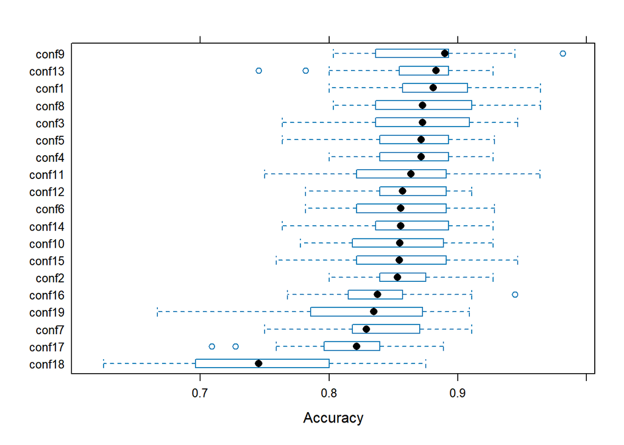

```r
# Graficar resultados
bwplot(resultados_resampling, metric = "Accuracy")
```

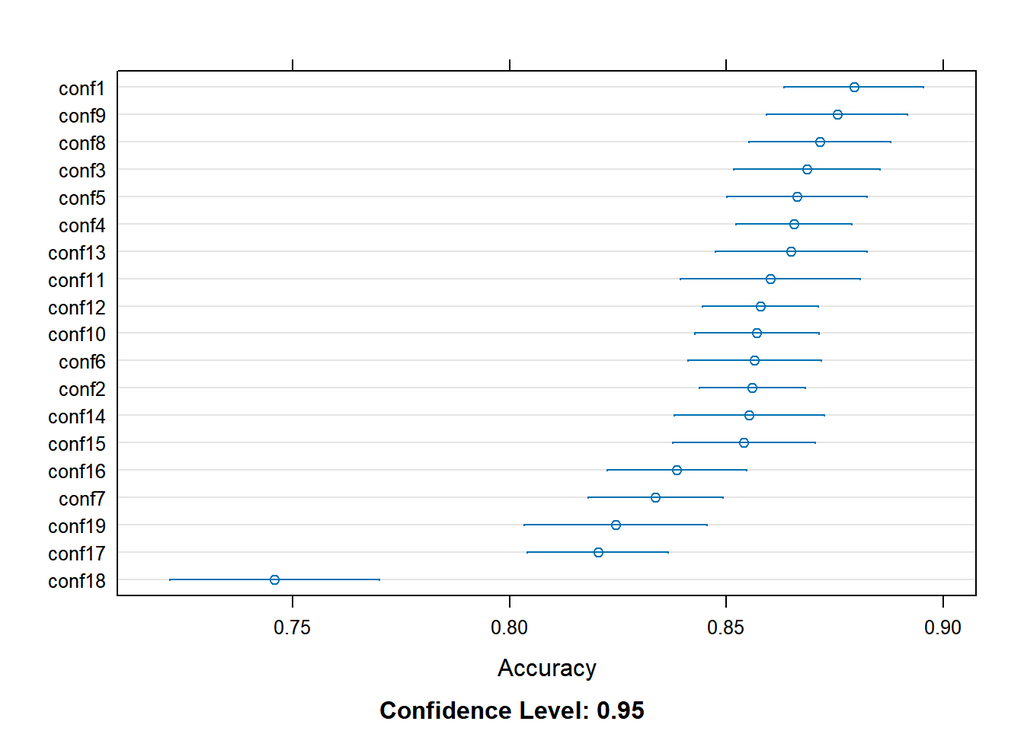

```r
dotplot(resultados_resampling, metric = "Accuracy")
```

```r
# Prueba estadística de diferencias
diferencias_modelos <- diff(resultados_resampling)
summary(diferencias_modelos)
```

```
##
## Call:
## summary.diff.resamples(object = diferencias_modelos)
##
## p-value adjustment: bonferroni
## Upper diagonal: estimates of the difference
## Lower diagonal: p-value for H0: difference = 0
##
## Accuracy
##        conf1     conf2      conf3      conf4      conf5      conf6
## conf1             0.0233886  0.0108153  0.0137779  0.0131337  0.0229441
## conf2  1.0000000            -0.0125734 -0.0096108 -0.0102549 -0.0004445
## conf3  1.0000000 1.0000000              0.0029626  0.0023184  0.0121288
## conf4  1.0000000 1.0000000  1.0000000             -0.0006441  0.0091663
## conf5  1.0000000 1.0000000  1.0000000  1.0000000              0.0098104
## conf6  1.0000000 1.0000000  1.0000000  1.0000000  1.0000000
## conf7  0.0387128 0.8078947  0.5303363  0.9955575  1.0000000  1.0000000
## conf8  1.0000000 1.0000000  1.0000000  1.0000000  1.0000000  1.0000000
## conf9  1.0000000 1.0000000  1.0000000  1.0000000  1.0000000  1.0000000
## conf10 1.0000000 1.0000000  1.0000000  1.0000000  1.0000000  1.0000000
## conf11 1.0000000 1.0000000  1.0000000  1.0000000  1.0000000  1.0000000
## conf12 1.0000000 1.0000000  1.0000000  1.0000000  1.0000000  1.0000000
## conf13 1.0000000 1.0000000  1.0000000  1.0000000  1.0000000  1.0000000
## conf14 1.0000000 1.0000000  1.0000000  1.0000000  1.0000000  1.0000000
## conf15 1.0000000 1.0000000  1.0000000  1.0000000  1.0000000  1.0000000
## conf16 0.6084051 1.0000000  0.4103036  1.0000000  1.0000000  1.0000000
## conf17 0.0011441 0.2359006  0.0147072  0.0554859  0.0196455  0.6778973
## conf18 2.054e-09 5.958e-06  3.906e-08  3.916e-07  1.422e-07  3.613e-06
## conf19 0.1730282 1.0000000  0.6914252  0.3985252  1.0000000  1.0000000
##        conf7      conf8      conf9      conf10     conf11     conf12
## conf1   0.0457067  0.0078455  0.0038781  0.0223874  0.0191727  0.0215989
## conf2   0.0223180 -0.0155431 -0.0195106 -0.0010013 -0.0042160 -0.0017897
## conf3   0.0348914 -0.0029698 -0.0069372  0.0115721  0.0083574  0.0107836
## conf4   0.0319288 -0.0059323 -0.0098998  0.0086095  0.0053948  0.0078211
## conf5   0.0325730 -0.0052882 -0.0092557  0.0092536  0.0060390  0.0084652
## conf6   0.0227625 -0.0150986 -0.0190661 -0.0005568 -0.0037714 -0.0013452
## conf7             -0.0378612 -0.0418286 -0.0233193 -0.0265340 -0.0241077
## conf8  0.2399019             -0.0039675  0.0145418  0.0113272  0.0137534
## conf9  0.0596733  1.0000000              0.0185093  0.0152946  0.0177209
## conf10 1.0000000  1.0000000  1.0000000             -0.0032147 -0.0007884
```

[output cut: 116 more lines]

```
## conf5   8.734e-02
## conf6   6.639e-02
## conf7   1.859e-02
## conf8   9.852e-02
## conf9   1.065e-01
## conf10  6.887e-02
## conf11  7.508e-02
## conf12  7.004e-02
## conf13  8.488e-02
## conf14  6.421e-02
## conf15  6.126e-02
## conf16  2.875e-02
## conf17 -8.994e-03
## conf18 -1.619e-01
## conf19
```

Basándonos en el gráfico, **conf1** parece ser la mejor configuración porque tiene la mayor media de Accuracy con un intervalo de confianza relativamente pequeño. Como podemos ver en la matriz de configuraciones, conf1 se corresponde al uso exclusivo de dummy.

Por lo tanto, antes de encontrar los mejores hiper-parámetros, debemos de guardar la configuración definitiva, que hemos dicho que será solo aplicando dummy:

```r
credit.Datos.gbm.Train <- credit.Datos.Train
credit.Datos.gbm.Test <- credit.Datos.Test

dummy("credit.Datos.gbm.Train", "credit.Datos.gbm.Test")

# Quitar variables con varianza cercana a cero
resultados <- eliminar_varianza_cero(credit.Datos.gbm.Train, credit.Datos.gbm.Test)
```

```
## [1] "Columnas Eliminadas por Varianza Cero:"
##  [1] "V5.gg"                  "V6.d"                   "V6.e"
##  [4] "V6.j"                   "V6.r"                   "V7.dd"
##  [7] "V7.j"                   "V7.n"                   "V7.o"
## [10] "V7.z"                   "composicionPoblacion.p"
## [1] "Verificación - Varianza Cero después de Eliminación:"
## [1] "Train: 0"
## [1] "Test: 1"
```

```r
# Actualizar los conjuntos de datos
credit.Datos.gbm.Train <- resultados$train
credit.Datos.gbm.Test <- resultados$test
```

### 6.1.9 Encontrar los mejores hiper-parámetros y ajustar modelo final

```r
library(caret)
library(gbm)
```

```r
# Configuración de la validación cruzada
# Hemos probado varias y la que mejor resultado ha dado es "repeatedcv"
credit.trainCtrl.3cv10.resampAll <- trainControl(
  method = "repeatedcv", # Validación cruzada de 10 pliegues
  number = 10,           # Número de pliegues
  repeats = 3,           # Repeticiones
  verboseIter = F,       # Voy a quitar Verbose porque inunda toda la pantalla
  returnResamp = "all"   # Guardar todos los resultados
)

# Rnago de hiperparámetros para GBM
gbm.grid <- expand.grid(
  n.trees = c(100, 500),              # Árboles limitados
  shrinkage = c(0.01, 0.1),           # Tasas de aprendizaje clave
  n.minobsinnode = c(5, 10),          # Nodos hijos mínimos
  interaction.depth = c(3, 5)         # Profundidad limitada
)

# Definir variables predictoras y objetivo
credit.Var.Salida.Usada <- "V16"
credit.Vars.Entrada.Usadas <- setdiff(names(credit.Datos.gbm.Train), credit.Var.Salida.Usada)

set.seed(2)
credit.modelo.3cv10.grid.gbm<-train(
  credit.Datos.gbm.Train[credit.Vars.Entrada.Usadas],
  credit.Datos.gbm.Train[[credit.Var.Salida.Usada]],
  method="gbm", trControl=credit.trainCtrl.3cv10.resampAll,
  tuneGrid = gbm.grid
,verbose=F
)

# Mostrar resultados
print(credit.modelo.3cv10.grid.gbm)
```

```
## Stochastic Gradient Boosting
##
## 553 samples
##  26 predictor
##   2 classes: 'rechazada', 'aprobada'
##
## No pre-processing
## Resampling: Cross-Validated (10 fold, repeated 3 times)
## Summary of sample sizes: 497, 498, 497, 497, 497, 497, ...
## Resampling results across tuning parameters:
##
##   shrinkage  interaction.depth  n.minobsinnode  n.trees  Accuracy   Kappa
##   0.01       3                   5              100      0.8673489  0.7329379
##   0.01       3                   5              500      0.8710185  0.7392794
##   0.01       3                  10              100      0.8685943  0.7348412
##   0.01       3                  10              500      0.8721978  0.7415202
##   0.01       5                   5              100      0.8764514  0.7500820
##   0.01       5                   5              500      0.8649892  0.7267668
##   0.01       5                  10              100      0.8752393  0.7473822
##   0.01       5                  10              500      0.8770471  0.7509803
##   0.10       3                   5              100      0.8644380  0.7256783
##   0.10       3                   5              500      0.8529754  0.7024230
##   0.10       3                  10              100      0.8710285  0.7385894
##   0.10       3                  10              500      0.8516863  0.6994508
##   0.10       5                   5              100      0.8686043  0.7340229
##   0.10       5                   5              500      0.8643707  0.7256952
##   0.10       5                  10              100      0.8698593  0.7366190
##   0.10       5                  10              500      0.8589490  0.7148276
##
## Accuracy was used to select the optimal model using the largest value.
## The final values used for the model were n.trees = 500, interaction.depth =
##  5, shrinkage = 0.01 and n.minobsinnode = 10.
```

```r
# Evaluación en el conjunto de test
predictions <- predict(credit.modelo.3cv10.grid.gbm, credit.Datos.gbm.Test)

# Calcular matriz de confusión y Accuracy
conf_mat <- confusionMatrix(predictions, credit.Datos.gbm.Test[[credit.Var.Salida.Usada]])

# Mostrar el porcentaje de acierto
accuracy <- conf_mat$overall["Accuracy"]
print(paste("Porcentaje de Acierto:", round(accuracy * 100, 2), "%"))
```

```
## [1] "Porcentaje de Acierto: 86.86 %"
```

Obtenemos un porcentaje de acierto de un 86.86% pero va a tener algo de peeking. Por lo tanto, vamos a hacer un entrenamiento final con hiper-parámetros fijos.

### 6.1.10 Entrenamos con hiper-parámetros fijos

Una vez hemos encontrado los mejores hiper-parámetros debemos de entrenar con dichos hiper-parámetros. Los que mejor resultado han dado son:  
Árboles seleccionados: 500  
Profundidad máxima: 5  
Tasa de aprendizaje: 0.01  
Mínimos nodos por hoja: 10  
Por lo tanto, vamos a entrenar con dichos hiper-parámetros:

```r
# Configuración para entrenamiento final
credit.trainCtrl.none <- trainControl(
  method = "none",  # Sin remuestreo
  classProbs = TRUE # Para calcular métricas de clasificación
)

# Hiperparámetros seleccionados previamente
best_hyperparams <- data.frame(
  n.trees = 500,              # Número de árboles
  interaction.depth = 5,      # Profundidad máxima
  shrinkage = 0.01,           # Tasa de aprendizaje
  n.minobsinnode = 10         # Nodos mínimos por hoja
)

# Definir variables predictoras y objetivo
credit.Var.Salida.Usada <- "V16"
credit.Vars.Entrada.Usadas <- setdiff(names(credit.Datos.gbm.Train), credit.Var.Salida.Usada)

# Entrenar el modelo final con los hiperparámetros fijos
set.seed(123)
modelo_final_gbm <- train(
  x = credit.Datos.gbm.Train[, credit.Vars.Entrada.Usadas],
  y = credit.Datos.gbm.Train[[credit.Var.Salida.Usada]],
  method = "gbm",
  trControl = credit.trainCtrl.none,
  tuneGrid = best_hyperparams,  # Hiperparámetros fijos
  metric = "Accuracy",          # Métrica de evaluación
  verbose = FALSE               # Sin salida en consola
)

# Evaluar el modelo final en el conjunto de prueba
predicciones <- predict(modelo_final_gbm, credit.Datos.gbm.Test)

# Calcular métricas de evaluación en el conjunto de prueba
library(caret)
confusion_matriz <- confusionMatrix(predicciones, credit.Datos.gbm.Test[[credit.Var.Salida.Usada]])

# Mostrar métricas de rendimiento
print(confusion_matriz)
```

```
## Confusion Matrix and Statistics
##
##            Reference
## Prediction  rechazada aprobada
##   rechazada        63        6
##   aprobada         13       55
##
##                Accuracy : 0.8613
##                  95% CI : (0.7919, 0.9144)
##     No Information Rate : 0.5547
##     P-Value [Acc > NIR] : 1.464e-14
##
##                   Kappa : 0.7224
##
##  Mcnemar's Test P-Value : 0.1687
##
##             Sensitivity : 0.8289
##             Specificity : 0.9016
##          Pos Pred Value : 0.9130
##          Neg Pred Value : 0.8088
##              Prevalence : 0.5547
##          Detection Rate : 0.4599
##    Detection Prevalence : 0.5036
##       Balanced Accuracy : 0.8653
##
##        'Positive' Class : rechazada
##
```

```r
print(paste("Porcentaje de Acierto:", round(confusion_matriz$overall["Accuracy"] * 100, 2), "%"))
```

```
## [1] "Porcentaje de Acierto: 86.13 %"
```

**Es importante destacar que:**  
Es curioso que en la búsqueda de hiper-parámetros obtengamos diferentes rendimientos que cuando “replicamos” el entrenamiento seleccionando ya los parámetros. Mientras en el primero obtenemos 86.86% en el otro obtenemos un 86.13%.

Para concluir, para gbm lo único realmente necesario es hacer Dummy, lo demás, para este caso y este modelo es innecesario.

Según hemos podido encontrar en esta página web: https://www.619.io/blog/2017/06/30/preliminary-investigation-pca-and-boosting/

“It is a bit disappointing to observe no improvement after reducing the number of features using PCA; and even worse, we get some noticeable degradation of the baseline result. Sometimes things like that happen… A more thorough feature tinkering might help here to reduce the number of features and achieve better performance!”

### 6.1.11 Conclusión:

Terminamos este entrenamiento habiendo probado muchísimas configuraciones de preprocesado (de forma automática), eligiendo la más prometedora, y buscando los parámetros idóneos que debería de tener nuestro modelo para obtener buenas predicciones. Siendo nuestro porcentaje de acierto experimental: 86.13%.

**Nota:** Cabe destacar que hemos probado otro tipo de preprocesados como la eliminación de variables no usadas con frecuencia, sin conseguir prácticamente ninguna mejora, por eso consideramos no ponerlo.

## 6.2 **SVM**

En primer lugar vamos a tratar de buscar información a cerca de las características del modelo. Gran parte de la información obtenida es de la siguiente pagina.  
https://medium.com/@vdeshpande551/understanding-the-inner-workings-of-svm-from-data-preprocessing-to-model-deployment-cdc9d72a2d34  
El modelo SVM (Support Vector Machines) funciona buscando el hiperplano óptimo que maximiza la separación entre las clases en el espacio de características. Por esta razón, SVM es sensible a la escala de los datos, ya que utiliza medidas de distancia. Por ello, probaremos varios modelos con diferentes métodos de escalado.

Además, es importante tener en cuenta que SVM no trabaja directamente con variables categóricas, por lo que será necesario transformarlas en dummies. Supondremos que todas las variables categóricas son de tipo ranked.

Otro aspecto necesario para que nuestro modelo funcione es eliminar las variables con poca correlación con la variable objetivo. También realizaremos otras pruebas, como:

- Reducir la dimensionalidad con diferentes métodos.
- Tratar los datos desbalanceados.
- Eliminar ciertas variables que no tengan importancia en el modelo final.

De este modo, porbaremos distintos preprocesados de datos con el objetivo de encontrar el que mejor rendimiento proporcione a nuestro model.

```r
credit.Datos.svm.Train <- credit.Datos.Train
credit.Datos.svm.Test <- credit.Datos.Test
```

### 6.2.1 Declaracion de funciones.

Para entrenar nuestro modelo, utilizaremos las funciones definidas en GBM. Sin embargo, añadiremos una nueva función para eliminar las variables con varianza igual a cero, de modo que podamos ejecutarla cuando sea necesario, en lugar de eliminar estas variables antes de entrenar el modelo, como se hacía en GBM.

```r
eliminar_varianza_cero_svm <- function(train_name, test_name) {
  train_data <- get(train_name, envir = .GlobalEnv)
  test_data <- get(test_name, envir = .GlobalEnv)


  nzv <- nearZeroVar(train_data)
  train_data_clean <- train_data[, -nzv]
  test_data_clean <- test_data[, names(train_data_clean)]

  assign(train_name, train_data_clean, envir = .GlobalEnv)
  assign(test_name, test_data_clean, envir = .GlobalEnv)
}
```

### 6.2.2 Configuración

```r
configuracion_svm <- list(
  conf1  = list("dummy", "var_cero"),
  conf2  = list("norm_center_scale", "dummy", "var_cero"),
  conf3  = list("norm_range", "dummy", "var_cero"),
  conf4  = list("dummy", "var_cero", "pca"),
  conf5  = list("dummy", "var_cero", "ica"),
  conf6  = list("norm_center_scale", "dummy", "var_cero", "pca"),
  conf7  = list("norm_center_scale", "dummy", "var_cero", "ica"),
  conf8  = list("norm_range", "dummy", "var_cero", "pca"),
  conf9  = list("norm_range", "dummy", "var_cero", "ica")
)
```

### 6.2.3 Ejecutar funciones según configuración

```r
ejecutar_configuracion_svm <- function(config, train, test) {
  if ("norm_range" %in% config) norm_range(train, test)
  if ("norm_center_scale" %in% config) norm_center_scale(train, test)
  if ("dummy" %in% config) dummy(train, test)
  if ("var_cero" %in% config) eliminar_varianza_cero_svm(train, test)
  if ("pca" %in% config) pca(train, test)
  if ("ica" %in% config) ica(train, test)
}
```

### 6.2.4 Almacenar modelos entrenados

```r
modelos_entrenados_svm <- list()
```

### 6.2.5 Ejecutamos todas las configuraciones

```r
for (i in seq_along(configuracion_svm)) {
  # Crear nombre de configuración
  nombre_config <- names(configuracion_svm)[i]
  preprocesamientos <- configuracion_svm[[i]]

  # Restaurar bases de datos originales
  credit.Datos.svm.Train <- credit.Datos.Train
  credit.Datos.svm.Test <- credit.Datos.Test

  # Aplicar configuración
  ejecutar_configuracion_svm(preprocesamientos, "credit.Datos.svm.Train", "credit.Datos.svm.Test")

  # Definir variables de entrada y salida
  credit.Var.Salida.Usada <- "V16"
  credit.Vars.Entrada.Usadas <- setdiff(names(credit.Datos.svm.Train), credit.Var.Salida.Usada)

  # Entrenar el modelo
  set.seed(1234)
  modelo_entrenado <- train(
    x = credit.Datos.svm.Train[, credit.Vars.Entrada.Usadas],
    y = credit.Datos.svm.Train[[credit.Var.Salida.Usada]],
    method = "svmRadial",
    trControl = credit.trainCtrl.3cv10.resampAll,
    tuneGrid = data.frame(
      sigma = 0.03951598,
      C = 1
    ),
    metric = "Accuracy",
    verbose = FALSE
  )

  # Guardar modelo
  modelos_entrenados_svm[[nombre_config]] <- modelo_entrenado

  # Mostrar información del modelo actual
  print(paste("Modelo entrenado para la configuración:", nombre_config))
}
```

```
## [1] "Modelo entrenado para la configuración: conf1"
## [1] "Modelo entrenado para la configuración: conf2"
## [1] "Modelo entrenado para la configuración: conf3"
## Created from 553 samples and 27 variables
##
## Pre-processing:
##   - centered (26)
##   - ignored (1)
##   - principal component signal extraction (26)
##   - scaled (26)
##
## PCA needed 19 components to capture 95 percent of the variance
## [1] "Modelo entrenado para la configuración: conf4"
## [1] "Modelo entrenado para la configuración: conf5"
## Created from 553 samples and 27 variables
##
## Pre-processing:
##   - centered (26)
##   - ignored (1)
##   - principal component signal extraction (26)
##   - scaled (26)
##
## PCA needed 19 components to capture 95 percent of the variance
## [1] "Modelo entrenado para la configuración: conf6"
## [1] "Modelo entrenado para la configuración: conf7"
## Created from 553 samples and 27 variables
##
## Pre-processing:
##   - centered (26)
##   - ignored (1)
##   - principal component signal extraction (26)
##   - scaled (26)
##
## PCA needed 19 components to capture 95 percent of the variance
## [1] "Modelo entrenado para la configuración: conf8"
## [1] "Modelo entrenado para la configuración: conf9"
```

### 6.2.6 Interpretamos los resultados obtenidos

```r
# Comparar modelos usando resamples()
resultados_resampling <- resamples(modelos_entrenados_svm)
# Mostrar estadísticas resumidas
summary(resultados_resampling)
```

```
##
## Call:
## summary.resamples(object = resultados_resampling)
##
## Models: conf1, conf2, conf3, conf4, conf5, conf6, conf7, conf8, conf9
## Number of resamples: 30
##
## Accuracy
##            Min.   1st Qu.    Median      Mean   3rd Qu.      Max. NA's
## conf1 0.7636364 0.8551948 0.8750000 0.8752225 0.9062500 0.9636364    0
## conf2 0.7636364 0.8551948 0.8750000 0.8752225 0.9062500 0.9636364    0
## conf3 0.7636364 0.8551948 0.8750000 0.8752225 0.9062500 0.9636364    0
## conf4 0.7090909 0.8008929 0.8363636 0.8336408 0.8688312 0.9074074    0
## conf5 0.7090909 0.8189935 0.8378247 0.8354926 0.8688312 0.9074074    0
## conf6 0.7090909 0.8008929 0.8363636 0.8336408 0.8688312 0.9074074    0
## conf7 0.7090909 0.8189935 0.8378247 0.8348866 0.8564935 0.9074074    0
## conf8 0.7090909 0.8008929 0.8363636 0.8336408 0.8688312 0.9074074    0
## conf9 0.7090909 0.8189935 0.8378247 0.8354926 0.8688312 0.9074074    0
##
## Kappa
##            Min.   1st Qu.    Median      Mean   3rd Qu.      Max. NA's
## conf1 0.5126108 0.7072571 0.7470930 0.7478531 0.8106224 0.9266667    0
## conf2 0.5126108 0.7072571 0.7470930 0.7478531 0.8106224 0.9266667    0
## conf3 0.5126108 0.7072571 0.7470930 0.7478531 0.8106224 0.9266667    0
## conf4 0.3914246 0.5909544 0.6693174 0.6582630 0.7284514 0.8117155    0
## conf5 0.3914246 0.6276446 0.6670937 0.6616077 0.7290152 0.8117155    0
## conf6 0.3914246 0.5909544 0.6693174 0.6582630 0.7284514 0.8117155    0
## conf7 0.3914246 0.6276446 0.6670937 0.6602971 0.7099901 0.8117155    0
## conf8 0.3914246 0.5909544 0.6693174 0.6582630 0.7284514 0.8117155    0
## conf9 0.3914246 0.6276446 0.6670937 0.6616077 0.7290152 0.8117155    0
```

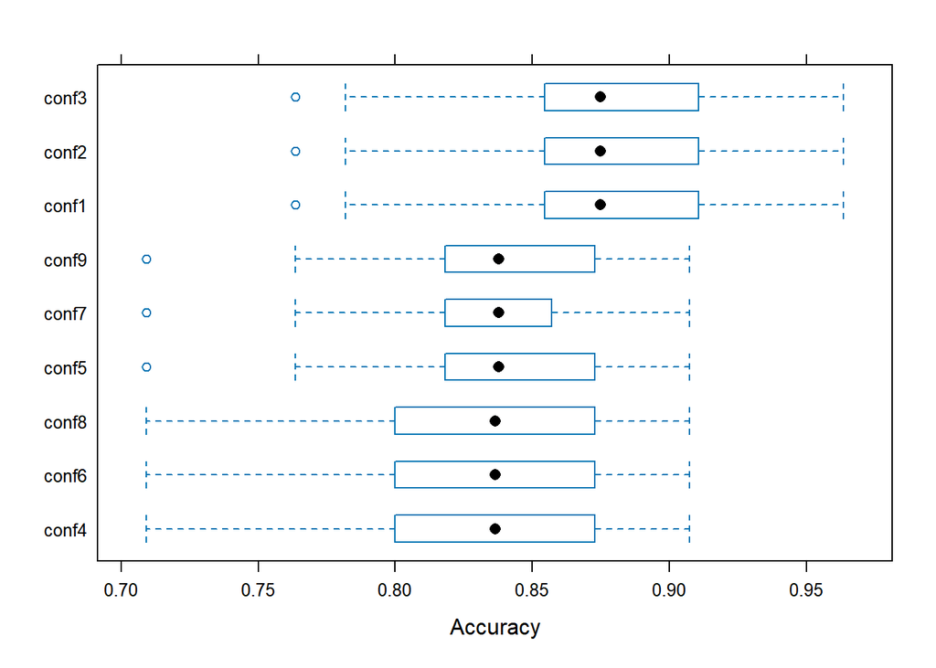

```r
# Graficar resultados
bwplot(resultados_resampling, metric = "Accuracy")
```

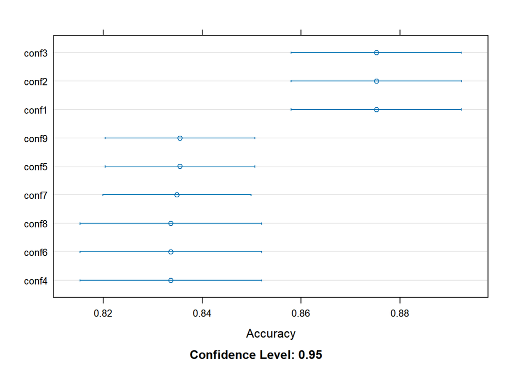

```r
dotplot(resultados_resampling, metric = "Accuracy")
```

```r
# Prueba estadística de diferencias
diferencias_modelos <- diff(resultados_resampling)
summary(diferencias_modelos)
```

```
##
## Call:
## summary.diff.resamples(object = diferencias_modelos)
##
## p-value adjustment: bonferroni
## Upper diagonal: estimates of the difference
## Lower diagonal: p-value for H0: difference = 0
##
## Accuracy
##       conf1     conf2      conf3      conf4      conf5      conf6
## conf1            0.0000000  0.0000000  0.0415817  0.0397298  0.0415817
## conf2 NA                    0.0000000  0.0415817  0.0397298  0.0415817
## conf3 NA        NA                     0.0415817  0.0397298  0.0415817
## conf4 6.049e-05 6.049e-05  6.049e-05             -0.0018519  0.0000000
## conf5 3.243e-06 3.243e-06  3.243e-06  1                      0.0018519
## conf6 6.049e-05 6.049e-05  6.049e-05  NA         1
## conf7 1.315e-06 1.315e-06  1.315e-06  1          1          1
## conf8 6.049e-05 6.049e-05  6.049e-05  NA         1          NA
## conf9 3.243e-06 3.243e-06  3.243e-06  1          NA         1
##       conf7      conf8      conf9
## conf1  0.0403359  0.0415817  0.0397298
## conf2  0.0403359  0.0415817  0.0397298
## conf3  0.0403359  0.0415817  0.0397298
## conf4 -0.0012458  0.0000000 -0.0018519
## conf5  0.0006061  0.0018519  0.0000000
## conf6 -0.0012458  0.0000000 -0.0018519
## conf7             0.0012458 -0.0006061
## conf8 1                     -0.0018519
## conf9 1          1
##
## Kappa
##       conf1     conf2     conf3     conf4     conf5     conf6     conf7
## conf1            0.000000  0.000000  0.089590  0.086245  0.089590  0.087556
## conf2 NA                   0.000000  0.089590  0.086245  0.089590  0.087556
## conf3 NA        NA                   0.089590  0.086245  0.089590  0.087556
## conf4 2.063e-05 2.063e-05 2.063e-05           -0.003345  0.000000 -0.002034
## conf5 6.479e-07 6.479e-07 6.479e-07 1                    0.003345  0.001311
## conf6 2.063e-05 2.063e-05 2.063e-05 NA        1                   -0.002034
## conf7 2.460e-07 2.460e-07 2.460e-07 1         1         1
## conf8 2.063e-05 2.063e-05 2.063e-05 NA        1         NA        1
## conf9 6.479e-07 6.479e-07 6.479e-07 1         NA        1         1
##       conf8     conf9
## conf1  0.089590  0.086245
## conf2  0.089590  0.086245
## conf3  0.089590  0.086245
## conf4  0.000000 -0.003345
## conf5  0.003345  0.000000
## conf6  0.000000 -0.003345
## conf7  0.002034 -0.001311
## conf8           -0.003345
## conf9 1
```

```r
credit.Datos.svm.Train <- credit.Datos.Train
credit.Datos.svm.Test <- credit.Datos.Test

dummy("credit.Datos.svm.Train", "credit.Datos.svm.Test")
eliminar_varianza_cero_svm("credit.Datos.svm.Train", "credit.Datos.svm.Test")
pca("credit.Datos.svm.Train", "credit.Datos.svm.Test")
```

```
## Created from 553 samples and 27 variables
##
## Pre-processing:
##   - centered (26)
##   - ignored (1)
##   - principal component signal extraction (26)
##   - scaled (26)
##
## PCA needed 19 components to capture 95 percent of the variance
```

### 6.2.7 Encontrar los mejores hiper-parámetros y ajustar modelo final

```r
set.seed(1234)
credit.modelo.svm <- train(
  V16 ~ .,
  data = credit.Datos.svm.Train,                    # Datos de entrenamiento
  method = "svmRadial",
  trControl = credit.trainCtrl.3cv10.resampAll,   # Validación cruzada d
  tuneLength = 20                                         # Probar diferentes valores de parámetros
)

#Mostrar porcentaje final
# Realizar predicciones en el conjunto de prueba
predicciones_test <- predict(credit.modelo.svm, credit.Datos.svm.Test)

# Generar la matriz de confusión
matriz_confusion <- confusionMatrix(predicciones_test, credit.Datos.svm.Test[[credit.Var.Salida.Usada]])

# Extraer el porcentaje de acierto
porcentaje_acierto <- matriz_confusion$overall["Accuracy"] * 100

# Mostrar el porcentaje de acierto
print(paste("Porcentaje de acierto:", round(porcentaje_acierto, 2), "%"))
```

```
## [1] "Porcentaje de acierto: 86.13 %"
```

Obtenemos un porcentaje de acierto de un 86.13% pero va a tener algo de peeking. Por lo tanto, vamos a hacer un entrenamiento final con hiper-parámetros fijos.

### 6.2.8 Entrenamos con hiper-parámetros fijos

Tras probar 20 combinaciones de hiper-parametros vamos a cuales han sido los que finalmente se han elegido para el modelo final.

```r
modelLookup(("svmRadial"))
```

|  | model | parameter | label | forReg | forClass | probModel |
| --- | --- | --- | --- | --- | --- | --- |
| 1 | svmRadial | sigma | Sigma | TRUE | TRUE | TRUE |
| 2 | svmRadial | C | Cost | TRUE | TRUE | TRUE |

El parámetro C es el parámetro de penalización, cuanto más altos sean los valores que este tome más estricto será, dando prioridad a clasificar correctamente todos los puntos. Con valores mas pequeños permite un margen más amplio, tolerando así más errores de clasificación.

El parámetro sigma, al igual que C cuanto mayor es su valor más cercanos serán los puntos considerados frontera de decisión y viceversa.

https://stackabuse.com/understanding-svm-hyperparameters/

Los hiper-parámetros de nuestro modelo final son los siguientes:

```r
credit.modelo.svm$bestTune
```

|  | sigma | C |
| --- | --- | --- |
| 3 | 0.03951598 | 1 |

```r
set.seed(2)
credit.modelo.final.svm <- train(
  V16 ~ .,
  data = credit.Datos.svm.Train,
  method = "svmRadial",
  trControl =  credit.trainCtrl.none,
  tuneGrid = data.frame(
    sigma = 0.03951598,
    C = 1
  ),
  metric = "Accuracy",          # Métrica de evaluación
  verbose = FALSE               # Sin salida en consola
)

# Evaluación en el conjunto de prueba
predictions <- predict(credit.modelo.final.svm, credit.Datos.svm.Test)

# Calcular matriz de confusión y accuracy
conf_mat <- confusionMatrix(predictions, credit.Datos.svm.Test[[credit.Var.Salida.Usada]])
accuracy <- conf_mat$overall["Accuracy"]

# Mostrar resultados
print(credit.modelo.final.svm)
```

```
## Support Vector Machines with Radial Basis Function Kernel
##
## 553 samples
##  19 predictor
##   2 classes: 'rechazada', 'aprobada'
##
## No pre-processing
## Resampling: None
```

```r
print(paste("Porcentaje de Acierto (Modelo Final):", round(accuracy * 100, 2), "%"))
```

```
## [1] "Porcentaje de Acierto (Modelo Final): 85.4 %"
```

### 6.2.9 Submuestreo con clases desvalanceadas

Para ver si nuestro modelo mejora vamos a tratar las clases desvalanceadas en el conjunto de los datos de entrenamiento.

```r
credit.Var.Salida.Usada <- c("V16")
credit.Vars.Entrada.Usadas <- setdiff(names(credit.Datos.svm.Train),credit.Var.Salida.Usada)
```

#### 6.2.9.1 down-sampling:

Consiste en reducir el número de ejemplos de las clases más frecuentes para igualar la clase menos frecuente.

```r
set.seed(12345)
credit.Datos.Train.svm.downsmpld<-downSample(x=credit.Datos.svm.Train[credit.Vars.Entrada.Usadas],
                                       y=credit.Datos.svm.Train[[credit.Var.Salida.Usada]],
                                       yname=credit.Var.Salida.Usada)
credit.Datos.Test.svm.downsmpld <- credit.Datos.svm.Test
```

#### 6.2.9.2 up-sampling:

En este caso hace lo contrario, remuestrea (con reemplazamiento) la clase minoritaria para igualarla a la mayoritaria (repite varios datos).

```r
set.seed(1234)
credit.Datos.Train.svm.upsmpld<-upSample(x=credit.Datos.svm.Train[credit.Vars.Entrada.Usadas],
                                   y=credit.Datos.svm.Train[[credit.Var.Salida.Usada]],
                                   yname=credit.Var.Salida.Usada)
credit.Datos.Test.svm.upsmpld<- credit.Datos.svm.Test
```

Creamos y probamos un modelo para cada una de estas configuraciones:

```r
set.seed(1234)
credit.modelo.svm.downsmpld <- train(
  V16 ~ .,  # Variable de salida ~ Variables de entrada
  data = credit.Datos.Train.svm.downsmpld,                                    # Datos de entrenamiento
  method = "svmRadial",
  trControl =  credit.trainCtrl.none,
  tuneGrid = data.frame(
    sigma = 0.03951598,
    C = 1
  ),
  metric = "Accuracy",          # Métrica de evaluación
  verbose = FALSE
)
#Mostrar porcentaje final
# Realizar predicciones en el conjunto de prueba
predicciones_test <- predict(credit.modelo.svm.downsmpld, credit.Datos.Test.svm.downsmpld)

# Generar la matriz de confusión
matriz_confusion <- confusionMatrix(predicciones_test, credit.Datos.Test.svm.downsmpld[[credit.Var.Salida.Usada]])

# Extraer el porcentaje de acierto
porcentaje_acierto <- matriz_confusion$overall["Accuracy"] * 100

# Mostrar el porcentaje de acierto
print(paste("Porcentaje de acierto:", round(porcentaje_acierto, 2), "%"))
```

```
## [1] "Porcentaje de acierto: 82.48 %"
```

```r
set.seed(1234)
credit.modelo.svm.upsmpld <- train(
  V16 ~ .,  # Variable de salida ~ Variables de entrada
  data = credit.Datos.Train.svm.upsmpld,                                    # Datos de entrenamiento
  method = "svmRadial",
  trControl =  credit.trainCtrl.none,
  tuneGrid = data.frame(
    sigma = 0.03951598,
    C = 1
  ),
  metric = "Accuracy",          # Métrica de evaluación
  verbose = FALSE
)
#Mostrar porcentaje final
# Realizar predicciones en el conjunto de prueba
predicciones_test <- predict(credit.modelo.svm.upsmpld, credit.Datos.Test.svm.upsmpld)

# Generar la matriz de confusión
matriz_confusion <- confusionMatrix(predicciones_test, credit.Datos.Test.svm.upsmpld[[credit.Var.Salida.Usada]])

# Extraer el porcentaje de acierto
porcentaje_acierto <- matriz_confusion$overall["Accuracy"] * 100

# Mostrar el porcentaje de acierto
print(paste("Porcentaje de acierto:", round(porcentaje_acierto, 2), "%"))
```

```
## [1] "Porcentaje de acierto: 81.75 %"
```

Como vemos, estos modelos no mejoran el porcentaje de acierto que teniamos.

### 6.2.10 Eliminación de variables

```r
#Ver importancia de las variables de entrada
#Metodo -> varImp()
varImp(credit.modelo.final.svm)
```

```
## ROC curve variable importance
##
##      Importance
## PC1    100.0000
## PC3     63.7263
## PC2     44.8465
## PC6     13.2947
## PC18    11.6747
## PC12    10.9810
## PC4     10.4371
## PC15     9.0379
## PC14     6.8464
## PC17     5.7704
## PC11     4.9860
## PC16     3.8114
## PC7      3.0901
## PC10     2.5541
## PC19     2.0102
## PC13     1.6751
## PC9      1.0090
## PC8      0.5991
## PC5      0.0000
```

```r
#Ver seleccion de variables del modelo
#Metodo -> predictors(modelo$finalModel)
predictors(credit.modelo.final.svm)
```

```
##  [1] "PC1"  "PC2"  "PC3"  "PC4"  "PC5"  "PC6"  "PC7"  "PC8"  "PC9"  "PC10"
## [11] "PC11" "PC12" "PC13" "PC14" "PC15" "PC16" "PC17" "PC18" "PC19"
```

Como vemos la variable PC5 no tiene importancia a la hora de realizar la clasificación. Vamos a probar a eliminarla para ver si nuestro modelo mejora.

```r
credit.Datos.Train.svm.Reduc <- credit.Datos.svm.Train
credit.Datos.Test.svm.Reduc <- credit.Datos.svm.Test
credit.Datos.Train.svm.Reduc$PC5 <- NULL
credit.Datos.Test.svm.Reduc$PC5 <- NULL
```

```r
set.seed(1234)
credit.modelo.svm.Reduc <- train(
  V16 ~ .,  # Variable de salida ~ Variables de entrada
  data = credit.Datos.Train.svm.Reduc,                                    # Datos de entrenamiento
  method = "svmRadial",
  trControl =  credit.trainCtrl.none,
  tuneGrid = data.frame(
    sigma = 0.03951598,
    C = 1
  ),
  metric = "Accuracy",          # Métrica de evaluación
  verbose = FALSE
)

predicciones_test <- predict(credit.modelo.svm.Reduc, credit.Datos.Test.svm.Reduc)

# Generar la matriz de confusión
matriz_confusion <- confusionMatrix(predicciones_test, credit.Datos.Test.svm.Reduc[[credit.Var.Salida.Usada]])

# Extraer el porcentaje de acierto
porcentaje_acierto <- matriz_confusion$overall["Accuracy"] * 100

# Mostrar el porcentaje de acierto
print(paste("Porcentaje de acierto:", round(porcentaje_acierto, 2), "%"))
```

```
## [1] "Porcentaje de acierto: 82.48 %"
```

Como podemos observar la eliminación de la variable PC5, que no tenía impotancia el modelo final entrenado, no supone un aumento en el porcentaje de acierto.

### 6.2.11 Conclusión

El modelo final sería:

```r
print(credit.modelo.final.svm)
```

```
## Support Vector Machines with Radial Basis Function Kernel
##
## 553 samples
##  19 predictor
##   2 classes: 'rechazada', 'aprobada'
##
## No pre-processing
## Resampling: None
```

## 6.3 **KNN**

K-Nearest Neighbors (KNN) es un algoritmo de clasificación que predice la clase de una observación en función de las k observaciones más cercanas en el espacio de características. En nuestro caso, nos interesa aplicar KNN para clasificación.

Debido a la forma en que funciona KNN, la normalización de los datos será fundamental, ya que el algoritmo depende de las distancias entre las observaciones. También será necesario transformar las variables categóricas en dummys, para que el modelo pueda manejarlas adecuadamente.

No nos centraremos tanto en la reducción de la dimensionalidad, ya que KNN no se ve tan afectado por la cantidad de características como otros algoritmos, aunque podría aplicarse si se considera necesario. Por último, realizaremos pruebas eliminando variables poco importantes y también trataremos el desbalanceo de clases o sesgos en los datos.

https://www.datacamp.com/tutorial/k-nearest-neighbors-knn-classification-with-r-tutorial

https://www.datacamp.com/tutorial/preprocessing-in-data-science-part-1-centering-scaling-and-knn

```r
credit.Datos.knn.Train <- credit.Datos.Train
credit.Datos.knn.Test <- credit.Datos.Test
```

### 6.3.1 Configuración

```r
configuracion_knn <- list(
  conf1  = list("dummy"),
  conf2  = list("norm_center_scale", "dummy"),
  conf3  = list("norm_range", "dummy"),
  conf4  = list("dummy", "pca"),
  conf5  = list("dummy", "ica"),
  conf6  = list("norm_center_scale", "dummy", "pca"),
  conf7  = list("norm_center_scale", "dummy", "ica"),
  conf8  = list("norm_range", "dummy", "var_cero", "pca"),
  conf9  = list("norm_range", "dummy", "var_cero", "ica"),
  conf10 = list("norm_center_scale", "dummy", "var_cero"),
  conf11 = list("norm_range", "dummy", "var_cero"),
  conf12 = list("dummy", "var_cero", "pca"),
  conf13 = list("dummy", "var_cero", "ica")
)
```

### 6.3.2 Almacenar modelos entrenados

```r
modelos_entrenados_knn <- list()
```

### 6.3.3 Ejecutamos todas las configuraciones

```r
for (i in seq_along(configuracion_knn)) {
  # Crear nombre de configuración
  nombre_config <- names(configuracion_knn)[i]
  preprocesamientos <- configuracion_knn[[i]]

  # Restaurar bases de datos originales
  credit.Datos.knn.Train <- credit.Datos.Train
  credit.Datos.knn.Test <- credit.Datos.Test

  # Aplicar configuración
  ejecutar_configuracion_svm(preprocesamientos, "credit.Datos.knn.Train", "credit.Datos.knn.Test")


  # Definir variables de entrada y salida
  credit.Var.Salida.Usada <- "V16"
  credit.Vars.Entrada.Usadas <- setdiff(names(credit.Datos.knn.Train), credit.Var.Salida.Usada)

  # Entrenar el modelo
  modelo_entrenado <- train(
    x = credit.Datos.knn.Train[, credit.Vars.Entrada.Usadas],
    y = credit.Datos.knn.Train[[credit.Var.Salida.Usada]],
    method = "knn",
    trControl = credit.trainCtrl,
    tuneGrid = data.frame(
      k = 13
    ),
    metric = "Accuracy"
  )

  # Guardar modelo
  modelos_entrenados_knn[[nombre_config]] <- modelo_entrenado

  # Mostrar información del modelo actual
  print(paste("Modelo entrenado para la configuración:", nombre_config))
}
```

```
## [1] "Modelo entrenado para la configuración: conf1"
## [1] "Modelo entrenado para la configuración: conf2"
## [1] "Modelo entrenado para la configuración: conf3"
## Created from 553 samples and 38 variables
##
## Pre-processing:
##   - centered (37)
##   - ignored (1)
##   - principal component signal extraction (37)
##   - scaled (37)
##
## PCA needed 27 components to capture 95 percent of the variance
## [1] "Modelo entrenado para la configuración: conf4"
## [1] "Modelo entrenado para la configuración: conf5"
## Created from 553 samples and 38 variables
##
## Pre-processing:
##   - centered (37)
##   - ignored (1)
##   - principal component signal extraction (37)
##   - scaled (37)
##
## PCA needed 27 components to capture 95 percent of the variance
## [1] "Modelo entrenado para la configuración: conf6"
## [1] "Modelo entrenado para la configuración: conf7"
## Created from 553 samples and 27 variables
##
## Pre-processing:
##   - centered (26)
##   - ignored (1)
##   - principal component signal extraction (26)
##   - scaled (26)
##
## PCA needed 19 components to capture 95 percent of the variance
## [1] "Modelo entrenado para la configuración: conf8"
## [1] "Modelo entrenado para la configuración: conf9"
## [1] "Modelo entrenado para la configuración: conf10"
## [1] "Modelo entrenado para la configuración: conf11"
## Created from 553 samples and 27 variables
##
## Pre-processing:
##   - centered (26)
##   - ignored (1)
##   - principal component signal extraction (26)
##   - scaled (26)
##
## PCA needed 19 components to capture 95 percent of the variance
## [1] "Modelo entrenado para la configuración: conf12"
## [1] "Modelo entrenado para la configuración: conf13"
```

### 6.3.4 Interpretamos los resultados obtenidos

```r
# Comparar modelos usando resamples()
resultados_resampling <- resamples(modelos_entrenados_knn)

# Mostrar estadísticas resumidas
summary(resultados_resampling)
```

```
##
## Call:
## summary.resamples(object = resultados_resampling)
##
## Models: conf1, conf2, conf3, conf4, conf5, conf6, conf7, conf8, conf9, conf10, conf11, conf12, conf13
## Number of resamples: 30
##
## Accuracy
##             Min.   1st Qu.    Median      Mean   3rd Qu.      Max. NA's
## conf1  0.5535714 0.6198864 0.6455026 0.6540055 0.6878247 0.7678571    0
## conf2  0.7090909 0.7883598 0.8198052 0.8240717 0.8571429 0.9285714    0
## conf3  0.7500000 0.8035714 0.8571429 0.8504662 0.8923701 0.9285714    0
## conf4  0.7222222 0.7500000 0.8198052 0.8081702 0.8392857 0.9107143    0
## conf5  0.6785714 0.8000000 0.8214286 0.8295867 0.8721380 0.9272727    0
## conf6  0.6785714 0.7827922 0.8198052 0.8113260 0.8487103 0.8750000    0
## conf7  0.7037037 0.7962963 0.8214286 0.8239614 0.8643669 0.8928571    0
## conf8  0.7090909 0.7534091 0.8000000 0.7948088 0.8206169 0.9107143    0
## conf9  0.7142857 0.7818182 0.8164983 0.8149054 0.8507305 0.8928571    0
## conf10 0.7407407 0.7818182 0.8198052 0.8141366 0.8392857 0.8750000    0
## conf11 0.7818182 0.8363636 0.8531987 0.8522194 0.8744318 0.9285714    0
## conf12 0.7142857 0.7636364 0.7981481 0.7963051 0.8214286 0.9090909    0
## conf13 0.6909091 0.7857143 0.8198052 0.8149387 0.8487103 0.9090909    0
##
## Kappa
##              Min.   1st Qu.    Median      Mean   3rd Qu.      Max. NA's
## conf1  0.09798658 0.2247607 0.2809691 0.2949975 0.3606520 0.5172414    0
## conf2  0.39310345 0.5617879 0.6270147 0.6358066 0.7064220 0.8532110    0
## conf3  0.47802929 0.5986925 0.7017310 0.6913905 0.7803654 0.8554839    0
## conf4  0.42060086 0.4872407 0.6270147 0.6038126 0.6710183 0.8186528    0
## conf5  0.32889481 0.5877541 0.6300957 0.6491044 0.7380091 0.8521505    0
## conf6  0.32889481 0.5529609 0.6294389 0.6099163 0.6908293 0.7441253    0
## conf7  0.39495798 0.5723483 0.6344591 0.6375433 0.7221929 0.7815345    0
## conf8  0.37940762 0.4874066 0.5856069 0.5752428 0.6323803 0.8186528    0
## conf9  0.40346205 0.5498103 0.6193361 0.6203907 0.6932648 0.7832258    0
## conf10 0.45217391 0.5463758 0.6265071 0.6142562 0.6679825 0.7441253    0
## conf11 0.54166667 0.6550027 0.6940100 0.6956366 0.7415891 0.8554839    0
## conf12 0.42637644 0.5053317 0.5811718 0.5782929 0.6323004 0.8125426    0
## conf13 0.37873754 0.5534831 0.6307030 0.6208170 0.6915030 0.8125426    0
```

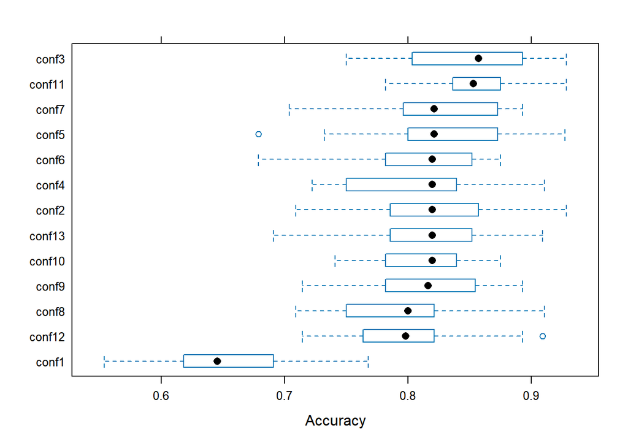

```r
# Graficar resultados
bwplot(resultados_resampling, metric = "Accuracy")
```

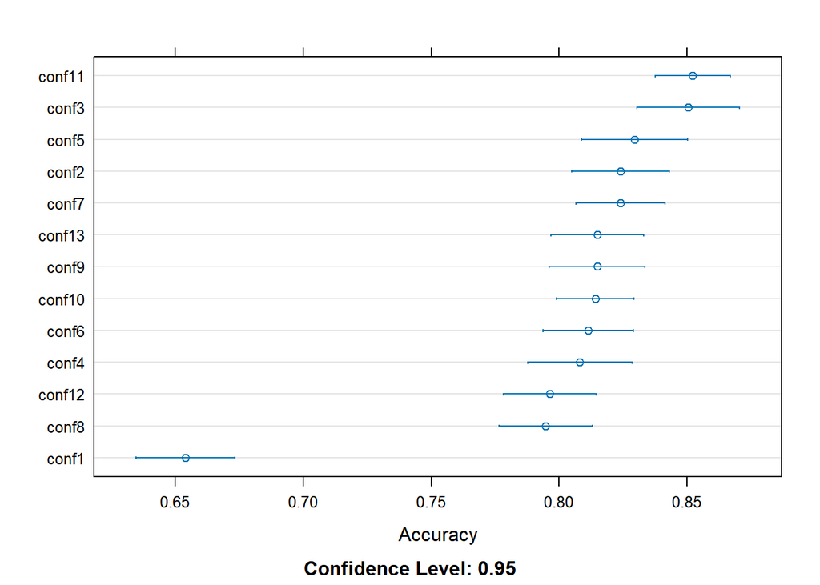

```r
dotplot(resultados_resampling, metric = "Accuracy")
```

```r
# Prueba estadística de diferencias
diferencias_modelos <- diff(resultados_resampling)
summary(diferencias_modelos)
```

```
##
## Call:
## summary.diff.resamples(object = diferencias_modelos)
##
## p-value adjustment: bonferroni
## Upper diagonal: estimates of the difference
## Lower diagonal: p-value for H0: difference = 0
##
## Accuracy
##        conf1     conf2      conf3      conf4      conf5      conf6
## conf1            -1.701e-01 -1.965e-01 -1.542e-01 -1.756e-01 -1.573e-01
## conf2  1.462e-12            -2.639e-02  1.590e-02 -5.515e-03  1.275e-02
## conf3  2.829e-12 1.000000               4.230e-02  2.088e-02  3.914e-02
## conf4  9.565e-09 1.000000   0.157248              -2.142e-02 -3.156e-03
## conf5  7.526e-11 1.000000   1.000000   1.000000               1.826e-02
## conf6  9.313e-11 1.000000   0.301576   1.000000   1.000000
## conf7  2.390e-11 1.000000   1.000000   1.000000   1.000000   1.000000
## conf8  3.844e-09 1.000000   0.042415   1.000000   1.000000   1.000000
## conf9  2.860e-11 1.000000   1.000000   1.000000   1.000000   1.000000
## conf10 8.462e-12 1.000000   0.292885   1.000000   1.000000   1.000000
## conf11 2.181e-14 1.000000   1.000000   0.433790   1.000000   0.113708
## conf12 2.681e-09 1.000000   0.020611   1.000000   0.753028   1.000000
## conf13 3.860e-12 1.000000   1.000000   1.000000   1.000000   1.000000
##        conf7      conf8      conf9      conf10     conf11     conf12
## conf1  -1.700e-01 -1.408e-01 -1.609e-01 -1.601e-01 -1.982e-01 -1.423e-01
## conf2   1.102e-04  2.926e-02  9.166e-03  9.935e-03 -2.815e-02  2.777e-02
## conf3   2.650e-02  5.566e-02  3.556e-02  3.633e-02 -1.753e-03  5.416e-02
## conf4  -1.579e-02  1.336e-02 -6.735e-03 -5.966e-03 -4.405e-02  1.187e-02
## conf5   5.625e-03  3.478e-02  1.468e-02  1.545e-02 -2.263e-02  3.328e-02
## conf6  -1.264e-02  1.652e-02 -3.579e-03 -2.811e-03 -4.089e-02  1.502e-02
## conf7              2.915e-02  9.056e-03  9.825e-03 -2.826e-02  2.766e-02
## conf8  0.739301              -2.010e-02 -1.933e-02 -5.741e-02 -1.496e-03
## conf9  1.000000   1.000000               7.688e-04 -3.731e-02  1.860e-02
## conf10 1.000000   1.000000   1.000000              -3.808e-02  1.783e-02
## conf11 1.000000   0.002358   0.186752   0.098314               5.591e-02
## conf12 1.000000   1.000000   1.000000   1.000000   0.002612
## conf13 1.000000   1.000000   1.000000   1.000000   0.358255   1.000000
##        conf13
## conf1  -1.609e-01
## conf2   9.133e-03
```

[output cut: 40 more lines]

```
## conf13 1.000000   1.000000   1.000000   1.000000   0.453989   1.000000
##        conf13
## conf1  -0.3258195
## conf2   0.0149896
## conf3   0.0705734
## conf4  -0.0170044
## conf5   0.0282873
## conf6  -0.0109008
## conf7   0.0167262
## conf8  -0.0455743
## conf9  -0.0004263
## conf10 -0.0065608
## conf11  0.0748195
## conf12 -0.0425241
## conf13
```

Aunque no podemos asegurar caul es la mejor ya que los intervalos coincide, nos vamos a quedar con la tercera configuración.

```r
credit.Datos.knn.Train <- credit.Datos.Train
credit.Datos.knn.Test <- credit.Datos.Test

norm_range("credit.Datos.knn.Train", "credit.Datos.knn.Test")
dummy("credit.Datos.knn.Train", "credit.Datos.knn.Test")
eliminar_varianza_cero_svm("credit.Datos.knn.Train", "credit.Datos.knn.Test")
```

### 6.3.5 Encontrar los mejores hiper-parámetros y ajustar modelo final

```r
# Configurar el modelo KNN
set.seed(1234)
# Entrenamiento del modelo k-NN
credit.modelo.knn <- train(
  V16 ~ .,
  data = credit.Datos.knn.Train,
  method = "knn",  # Especificamos k-NN
  trControl = credit.trainCtrl,
  tuneLength = 20)

#Mostrar porcentaje final
# Realizar predicciones en el conjunto de prueba
predicciones_test <- predict(credit.modelo.knn, credit.Datos.knn.Test)

# Generar la matriz de confusión
matriz_confusion <- confusionMatrix(predicciones_test, credit.Datos.knn.Test[[credit.Var.Salida.Usada]])

# Extraer el porcentaje de acierto
porcentaje_acierto <- matriz_confusion$overall["Accuracy"] * 100

# Mostrar el porcentaje de acierto
print(paste("Porcentaje de acierto:", round(porcentaje_acierto, 2), "%"))
```

```
## [1] "Porcentaje de acierto: 87.59 %"
```

### 6.3.6 Entrenamos con hiper-parámetros fijos

Tras probar 20 combinaciones de hiper-parametros vamos a cuales han sido los que finalmente se han elegido para el modelo final.

```r
modelLookup(("knn"))
```

|  | model | parameter | label | forReg | forClass | probModel |
| --- | --- | --- | --- | --- | --- | --- |
| 1 | knn | k | #Neighbors | TRUE | TRUE | TRUE |

El parámetro k en K-Nearest Neighbors (KNN) representa el número de vecinos más cercanos que se consideran para hacer una predicción.

- Valor pequeño de k: El modelo es más sensible al ruido y puede sobreajustarse, ya que se basa solo en los pocos vecinos más cercanos.
- Valor grande de k: El modelo es más general y robusto, ya que considera una mayor cantidad de vecinos, pero puede subajustarse si se elige un valor demasiado grande.

```r
credit.modelo.knn$bestTune
```

|  | k |
| --- | --- |
| 2 | 7 |

En nuestro caso k=7 proporcionara un equilibrio entre la sensibilidad al ruido y la generalidad.

Vamos a entrenar un modelo finjando el número de vecinos mas cercano.

```r
set.seed(2)
credit.modelo.final.knn <- train(
  V16 ~ .,
  data = credit.Datos.knn.Train,
  method = "knn",
  trControl =  credit.trainCtrl.none,
  tuneGrid = data.frame(
    k = 7
  ),
  metric = "Accuracy"          # Métrica de evaluación
)

# Evaluación en el conjunto de prueba
predictions <- predict(credit.modelo.final.knn, credit.Datos.knn.Test)

# Calcular matriz de confusión y accuracy
conf_mat <- confusionMatrix(predictions, credit.Datos.knn.Test[[credit.Var.Salida.Usada]])
accuracy <- conf_mat$overall["Accuracy"]

# Mostrar resultados
print(credit.modelo.final.knn)
```

```
## k-Nearest Neighbors
##
## 553 samples
##  26 predictor
##   2 classes: 'rechazada', 'aprobada'
##
## No pre-processing
## Resampling: None
```

```r
print(paste("Porcentaje de Acierto (Modelo Final):", round(accuracy * 100, 2), "%"))
```

```
## [1] "Porcentaje de Acierto (Modelo Final): 87.59 %"
```

### 6.3.7 Submuestreo con clases desvalanceadas

Para ver si nuestro modelo mejora vamos a tratar las clases desvalanceadas en el conjunto de los datos de entrenamiento.

```r
credit.Var.Salida.Usada <- c("V16")
credit.Vars.Entrada.Usadas <- setdiff(names(credit.Datos.knn.Train),credit.Var.Salida.Usada)
```

#### 6.3.7.1 down-sampling:

Consiste en reducir el número de ejemplos de las clases más frecuentes para igualar la clase menos frecuente.

```r
set.seed(12345)
credit.Datos.Train.knn.downsmpld<-downSample(x=credit.Datos.knn.Train[credit.Vars.Entrada.Usadas],
                                       y=credit.Datos.knn.Train[[credit.Var.Salida.Usada]],
                                       yname=credit.Var.Salida.Usada)
credit.Datos.Test.knn.downsmpld <- credit.Datos.knn.Test
```

#### 6.3.7.2 up-sampling:

En este caso hace lo contrario, remuestrea (con reemplazamiento) la clase minoritaria para igualarla a la mayoritaria (repite varios datos).

```r
set.seed(1234)
credit.Datos.Train.knn.upsmpld<-upSample(x=credit.Datos.knn.Train[credit.Vars.Entrada.Usadas],
                                   y=credit.Datos.knn.Train[[credit.Var.Salida.Usada]],
                                   yname=credit.Var.Salida.Usada)
credit.Datos.Test.knn.upsmpld<- credit.Datos.knn.Test
```

Creamos y probamos un modelo para cada una de estas configuraciones:

```r
set.seed(1234)
credit.modelo.knn.downsmpld <- train(
  V16 ~ .,  # Variable de salida ~ Variables de entrada
  data = credit.Datos.Train.knn.downsmpld,                                    # Datos de entrenamiento
  method = "knn",
  trControl =  credit.trainCtrl.none,
  tuneGrid = data.frame(
    k = 7
  ),
  metric = "Accuracy"
)
#Mostrar porcentaje final
# Realizar predicciones en el conjunto de prueba
predicciones_test <- predict(credit.modelo.knn.downsmpld, credit.Datos.Test.knn.downsmpld)

# Generar la matriz de confusión
matriz_confusion <- confusionMatrix(predicciones_test, credit.Datos.Test.knn.downsmpld[[credit.Var.Salida.Usada]])

# Extraer el porcentaje de acierto
porcentaje_acierto <- matriz_confusion$overall["Accuracy"] * 100

# Mostrar el porcentaje de acierto
print(paste("Porcentaje de acierto:", round(porcentaje_acierto, 2), "%"))
```

```
## [1] "Porcentaje de acierto: 86.86 %"
```

```r
set.seed(1234)
credit.modelo.knn.upsmpld <- train(
  V16 ~ .,  # Variable de salida ~ Variables de entrada
  data = credit.Datos.Train.knn.upsmpld,                                    # Datos de entrenamiento
  method = "knn",
  trControl =  credit.trainCtrl.none,
  tuneGrid = data.frame(
    k = 7
  ),
  metric = "Accuracy"
)
#Mostrar porcentaje final
# Realizar predicciones en el conjunto de prueba
predicciones_test <- predict(credit.modelo.knn.upsmpld, credit.Datos.Test.knn.upsmpld)

# Generar la matriz de confusión
matriz_confusion <- confusionMatrix(predicciones_test, credit.Datos.Test.knn.upsmpld[[credit.Var.Salida.Usada]])

# Extraer el porcentaje de acierto
porcentaje_acierto <- matriz_confusion$overall["Accuracy"] * 100

# Mostrar el porcentaje de acierto
print(paste("Porcentaje de acierto:", round(porcentaje_acierto, 2), "%"))
```

```
## [1] "Porcentaje de acierto: 86.13 %"
```

### 6.3.8 Eliminación de variables

```r
#Ver importancia de las variables de entrada
#Metodo -> varImp()
varImp(credit.modelo.final.knn)
```

```
## ROC curve variable importance
##
##   only 20 most important variables shown (out of 26)
##
##                        Importance
## V9.t                      100.000
## Solvencia                  70.887
## Empleado.t                 60.933
## AnyosContratado            59.030
## V15                        40.886
## Deuda                      30.604
## Edad                       21.993
## V5.p                       20.759
## EstadoCivil.y              20.759
## V14                        20.220
## V7.h                       19.771
## EstadoCivil.u              19.640
## V7.ff                      14.008
## V6.ff                      13.000
## V6.x                       12.856
## V6.q                       11.389
## V6.cc                      10.503
## V6.i                       10.202
## V6.k                        8.853
## composicionPoblacion.s      8.742
```

```r
#Ver seleccion de variables del modelo
#Metodo -> predictors(modelo$finalModel)
predictors(credit.modelo.final.knn)
```

```
##  [1] "Genero.b"               "Edad"                   "Deuda"
##  [4] "EstadoCivil.u"          "EstadoCivil.y"          "V5.p"
##  [7] "V6.c"                   "V6.cc"                  "V6.ff"
## [10] "V6.i"                   "V6.k"                   "V6.m"
## [13] "V6.q"                   "V6.w"                   "V6.x"
## [16] "V7.ff"                  "V7.h"                   "V7.v"
## [19] "AnyosContratado"        "V9.t"                   "Empleado.t"
## [22] "Solvencia"              "V12.t"                  "composicionPoblacion.s"
## [25] "V14"                    "V15"
```

En este caso, no hay variables que no se empleen o que tengan poca importancia.

### 6.3.9 Conclusión

Para el modelo de Knn, el mejor resultado lo obtenemos tras una normalización y la transformación de las variables categóricas y la eliminación de la variables con varianza 0. El modelo obtendría un porcentaje de acierto de 87.59 %.

```r
print(credit.modelo.knn)
```

```
## k-Nearest Neighbors
##
## 553 samples
##  26 predictor
##   2 classes: 'rechazada', 'aprobada'
##
## No pre-processing
## Resampling: Cross-Validated (10 fold, repeated 3 times)
## Summary of sample sizes: 497, 498, 497, 497, 498, 498, ...
## Resampling results across tuning parameters:
##
##   k   Accuracy   Kappa
##    5  0.8571922  0.7064877
##    7  0.8625277  0.7175296
##    9  0.8571493  0.7059818
##   11  0.8589562  0.7096859
##   13  0.8571268  0.7054754
##   15  0.8541290  0.6990554
##   17  0.8535121  0.6978592
##   19  0.8523000  0.6950949
##   21  0.8498974  0.6900871
##   23  0.8462939  0.6825298
##   25  0.8474948  0.6850719
##   27  0.8474731  0.6849710
##   29  0.8468891  0.6834372
##   31  0.8457095  0.6810442
##   33  0.8481121  0.6859770
##   35  0.8487077  0.6871020
##   37  0.8475060  0.6845193
##   39  0.8462831  0.6818609
##   41  0.8456874  0.6806155
##   43  0.8462827  0.6817656
##
## Accuracy was used to select the optimal model using the largest value.
## The final value used for the model was k = 7.
```

## 6.4 **Random Forest**

El Random Forest es un algoritmo de aprendizaje automático basado en un conjunto de árboles de decisión. Es especialmente util para tareas de clasificacion por lo tanto es un buen candidato para usarlo en esta tarea.

Para empezar vamos a ver que hiperparametros nos ofrece caret del random forest..

```r
modelLookup(("rf"))
```

|  | model | parameter | label | forReg | forClass | probModel |
| --- | --- | --- | --- | --- | --- | --- |
| 1 | rf | mtry | #Randomly Selected Predictors | TRUE | TRUE | TRUE |

En este caso solo disponemos de un hiperparámetro gestionado por caret, esto significa que en tuneGrid no podemos sponer mas hiperparametros de random forest porque caret no lo sabe gestionar por lo que tendremos que introducirlos manualmente en el train(). Dentro de los demas hiperparamentros existentes vamos a probar tambien ntree que es el numero de arboles de decision, para ello crearemos un bucle y entrenaremos modelos segun para cada numero de arboles.

### 6.4.1 Preprocesado de datos

En cuanto al preprocesado de datos para random forest no es muy exigente. RF no se ve afectado por la escala de las variables porque utiliza arboles de decision por lo tanto obviamos la normalizacion. RF tambien maneja bastante bien las variables altamente correlacionadas.

Lo que no sabe gestioniar RF son los valores NA pero como nuestras bases de entrenamiento han sido tratadas previamente en el preprocesado de datos para valores nulos no haria falta hacer mas.

```r
varObjetivo <- "V16"
varsPredictoras <- setdiff(names(credit.Datos.Train.imp), varObjetivo)
```

### 6.4.2 Entrenamiento

Vamos usar trainControl() para configurar procesos del entrenamiento donde vamos a poner una configuracion habitual recomendada por el caret la cual consiste en cross validacion cruzada de 10 plieges y 3 repeticiones. Ademas vamos a usar twoClassSummary junto con ROC ya que proporciona métricas robustas que evalúan el desempeño del modelo considerando todos los posibles umbrales de decisión. ROC es especialmente útil para comparar modelos, ya que mide la capacidad de separar correctamente las clases positivas y negativas, independientemente del balanceo entre ellas.

```r
rf.trainControl.3cv10.twoSummary.roc <- trainControl(
  method = "repeatedcv",
  number = 10,
  repeats = 3,
  # No mostramos el proceso porque seria muy extenso
  verboseIter = FALSE,
  # Métricas adicionales como ROC (para clasificación binaria)
  summaryFunction = twoClassSummary,
  # Necesario si queremos usar roc
  classProbs = TRUE,
  # Guardamos todo para hacer diagramas
  returnResamp = "all"
)
```

Creamos el grid para el hiperparametros mtry.

```r
rf.grid <- expand.grid(mtry = c(1, 2, 4, 6, 10))
```

Ahora procedemos a entrenar nuestro primer modelo de random forest. Vamos a realizar tres entrenamientos cada uno con un número de arboles distinto, ya que como hemos mencionado anteriormente al ser el numero de arboles un hiperparametros que no gestiona caret hay que ponerlo directamente en el train().

```r
# Entrenamiento para 100 arboles
set.seed(123)
rf.modelo.3cv10.twoSummary.roc.100 <- train(
  x = credit.Datos.Train.imp[varsPredictoras],
  y = credit.Datos.Train.imp[[varObjetivo]],
  method = "rf",
  metric = "ROC",
  trControl = rf.trainControl.3cv10.twoSummary.roc,
  tuneGrid = rf.grid,
  ntree = 100
)

# Entrenamiento para 500 arboles
set.seed(123)
rf.modelo.3cv10.twoSummary.roc.500 <- train(
  x = credit.Datos.Train.imp[varsPredictoras],
  y = credit.Datos.Train.imp[[varObjetivo]],
  method = "rf",
  metric = "ROC",
  trControl = rf.trainControl.3cv10.twoSummary.roc,
  tuneGrid = rf.grid,
  ntree = 500
)

# Entrenamiento para 1000 arboles
set.seed(123)
rf.modelo.3cv10.twoSummary.roc.1000 <- train(
  x = credit.Datos.Train.imp[varsPredictoras],
  y = credit.Datos.Train.imp[[varObjetivo]],
  method = "rf",
  metric = "ROC",
  trControl = rf.trainControl.3cv10.twoSummary.roc,
  tuneGrid = rf.grid,
  ntree = 1000
)
```

Vamos a ver con el siguiente código cual es el maximo ROC de cada uno de los modelos y para que hiperparametro, recordemos que cuanto más cercanos sea el ROC a uno mejores predicciones tendrá el modelo.

```r
maxIndexRf100 <- which.max(rf.modelo.3cv10.twoSummary.roc.100$results$ROC)

# Obtener los valores correspondientes
maxRocRf100 <- rf.modelo.3cv10.twoSummary.roc.100$results$ROC[maxIndexRf100]

mtry100 <- rf.modelo.3cv10.twoSummary.roc.100$results$mtry[maxIndexRf100]

# Imprimir los resultados
cat("El valor más alto de ROC para 100 arboles es:", maxRocRf100, "\n")
```

```
## El valor más alto de ROC para 100 arboles es: 0.9342308
```

```r
cat("Corresponde a mtry:", mtry100, "\n")
```

```
## Corresponde a mtry: 6
```

```r
maxIndexRf500 <- which.max(rf.modelo.3cv10.twoSummary.roc.500$results$ROC)

# Obtener los valores correspondientes
maxRocRf500 <- rf.modelo.3cv10.twoSummary.roc.500$results$ROC[maxIndexRf500]

mtry500 <- rf.modelo.3cv10.twoSummary.roc.500$results$mtry[maxIndexRf500]

# Imprimir los resultados
cat("El valor más alto de ROC para 500 arboles es:", maxRocRf500, "\n")
```

```
## El valor más alto de ROC para 500 arboles es: 0.9353125
```

```r
cat("Corresponde a mtry:", mtry500, "\n")
```

```
## Corresponde a mtry: 4
```

```r
maxIndexRf1000 <- which.max(rf.modelo.3cv10.twoSummary.roc.1000$results$ROC)

# Obtener los valores correspondientes
maxRocRf1000 <- rf.modelo.3cv10.twoSummary.roc.1000$results$ROC[maxIndexRf1000]

mtry1000 <- rf.modelo.3cv10.twoSummary.roc.1000$results$mtry[maxIndexRf1000]

# Imprimir los resultados
cat("El valor más alto de ROC para 1000 arboles es:", maxRocRf1000, "\n")
```

```
## El valor más alto de ROC para 1000 arboles es: 0.9353197
```

```r
cat("Corresponde a mtry:", mtry1000, "\n")
```

```
## Corresponde a mtry: 4
```

Ahora veamos una comparativa segun el nummero de arboles.

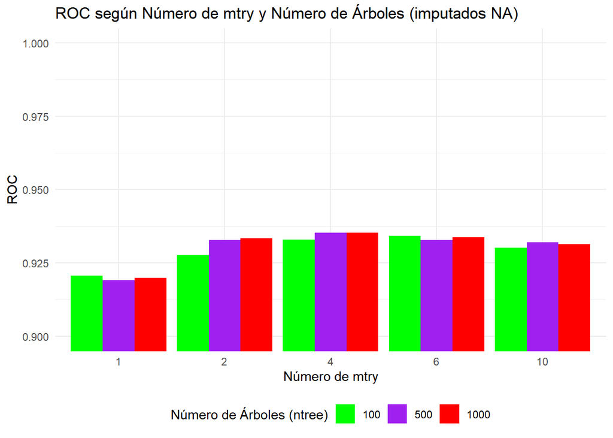

```r
# Crear un data.frame con los resultados
resultados_df <- data.frame(
  mtry = rep(c(1, 2, 4, 6, 10), times = 3), # Repetimos 5 valores de mtry, una vez por modelo
  ntree = rep(c(100, 500, 1000), each = 5), # 3 modelos, cada uno con 5 valores de mtry
  ROC = c(
    rf.modelo.3cv10.twoSummary.roc.100$results$ROC[1:5],
    rf.modelo.3cv10.twoSummary.roc.500$results$ROC[1:5],
    rf.modelo.3cv10.twoSummary.roc.1000$results$ROC[1:5]
  )
)

# Crear el histograma
ggplot(resultados_df, aes(x = as.factor(mtry), y = ROC, fill = as.factor(ntree))) +
  geom_bar(stat = "identity", position = "dodge") +
  labs(
    title = "ROC según Número de mtry y Número de Árboles (imputados NA)",
    x = "Número de mtry",
    y = "ROC",
    fill = "Número de Árboles (ntree)"
  ) +
  scale_fill_manual(values = c("100" = "green", "500" = "purple", "1000" = "red")) +
  theme_minimal() +
  theme(legend.position = "bottom") +
  coord_cartesian(ylim = c(0.9, 1))
```

Se puede ver que la diferencia entre 500 y 1000 arboles es muy pequeña por lo que poner 1000 arboles no merece la pena ya que conlleva mucho tiempo de ejecución.

### 6.4.3 Test de modelos

Probamos los distintos modelos que hemos entrenado para ver cual tiene mejor prediccion, esto lo hacemos sobre nuestro conjunto test.

```r
# Entrenamiento con valores NA imputados
prediccion.rf.modelo.3cv10.twoSummary.roc.100 <- predict(rf.modelo.3cv10.twoSummary.roc.100, newdata = credit.Datos.Test.imp[varsPredictoras])

prediccion.rf.modelo.3cv10.twoSummary.roc.500 <- predict(rf.modelo.3cv10.twoSummary.roc.500, newdata = credit.Datos.Test.imp[varsPredictoras])

prediccion.rf.modelo.3cv10.twoSummary.roc.1000 <- predict(rf.modelo.3cv10.twoSummary.roc.1000, newdata = credit.Datos.Test.imp[varsPredictoras])
```

### 6.4.4 Comparativa de modelos

Veamos los resultados

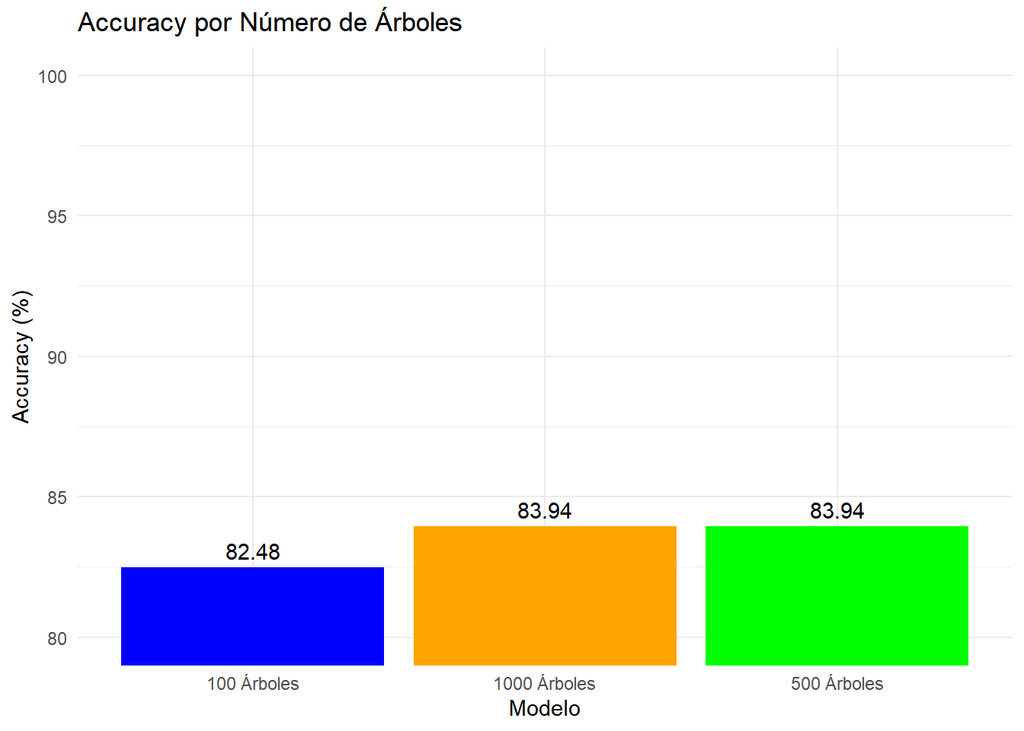

```r
# Generar matriz de confusión
matrizConfusion.rf.modelo.3cv10.twoSummary.roc.100 <- confusionMatrix(
  data = prediccion.rf.modelo.3cv10.twoSummary.roc.100,
  reference = credit.Datos.Test[[varObjetivo]],
  positive = "aprobada" # Cambia esto por la clase objetivo positiva
)

matrizConfusion.rf.modelo.3cv10.twoSummary.roc.500 <- confusionMatrix(
  data = prediccion.rf.modelo.3cv10.twoSummary.roc.500,
  reference = credit.Datos.Test[[varObjetivo]],
  positive = "aprobada" # Cambia esto por la clase objetivo positiva
)

matrizConfusion.rf.modelo.3cv10.twoSummary.roc.1000 <- confusionMatrix(
  data = prediccion.rf.modelo.3cv10.twoSummary.roc.1000,
  reference = credit.Datos.Test[[varObjetivo]],
  positive = "aprobada" # Cambia esto por la clase objetivo positiva
)


# Extraer Accuracy de las matrices de confusión
accuracy_imputados <- c(
  matrizConfusion.rf.modelo.3cv10.twoSummary.roc.100$overall["Accuracy"] * 100,
  matrizConfusion.rf.modelo.3cv10.twoSummary.roc.500$overall["Accuracy"] * 100,
  matrizConfusion.rf.modelo.3cv10.twoSummary.roc.1000$overall["Accuracy"] * 100
)

# Crear un data frame con los resultados
resultados <- data.frame(
  Modelo = c("100 Árboles", "500 Árboles", "1000 Árboles"),
  Accuracy = accuracy_imputados
)

# Cargar ggplot2
library(ggplot2)

# Crear el histograma
ggplot(resultados, aes(x = Modelo, y = Accuracy, fill = Modelo)) +
  geom_bar(stat = "identity", position = "dodge") +
  geom_text(aes(label = round(Accuracy, 2)), vjust = -0.5) + # Agregar etiquetas con valores
  labs(
    title = "Accuracy por Número de Árboles",
    x = "Modelo",
    y = "Accuracy (%)"
  ) +
  scale_fill_manual(values = c("100 Árboles" = "blue", "500 Árboles" = "green", "1000 Árboles" = "orange")) +
  theme_minimal() +
  coord_cartesian(ylim = c(80, 100)) +
  theme(legend.position = "none")
```

### 6.4.5 Reentrenamiento y testeo

```r
rf.grid.final.2 <- expand.grid(mtry = c(2))
rf.grid.final.4 <- expand.grid(mtry = c(4))


rf.modelo.3cv10.twoSummary.roc.100.final <- train(
  x = credit.Datos.Train.imp[varsPredictoras],
  y = credit.Datos.Train.imp[[varObjetivo]],
  method = "rf",
  metric = "ROC",
  trControl = rf.trainControl.3cv10.twoSummary.roc,
  tuneGrid = rf.grid.final.2,
  ntree = 100
)

rf.modelo.3cv10.twoSummary.roc.500.final <- train(
  x = credit.Datos.Train.imp[varsPredictoras],
  y = credit.Datos.Train.imp[[varObjetivo]],
  method = "rf",
  metric = "ROC",
  trControl = rf.trainControl.3cv10.twoSummary.roc,
  tuneGrid = rf.grid.final.4,
  ntree = 500
)
```

Vamos a probar si ha dado mejores predicciones.

```r
prediccion.rf.modelo.3cv10.twoSummary.roc.100.final <- predict(rf.modelo.3cv10.twoSummary.roc.100.final, newdata = credit.Datos.Test.imp[varsPredictoras])

prediccion.rf.modelo.3cv10.twoSummary.roc.500.final <- predict(rf.modelo.3cv10.twoSummary.roc.500.final, newdata = credit.Datos.Test.imp[varsPredictoras])
```

Vamos a comparar resultados.

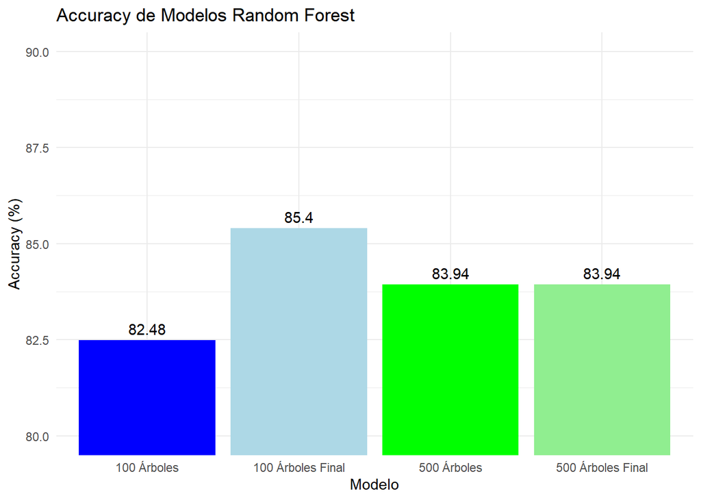

```r
matrizConfusion.rf.modelo.3cv10.twoSummary.roc.100.final <- confusionMatrix(
  data = prediccion.rf.modelo.3cv10.twoSummary.roc.100.final,
  reference = credit.Datos.Test[[varObjetivo]],
  positive = "aprobada" # Cambia esto por la clase objetivo positiva
)

matrizConfusion.rf.modelo.3cv10.twoSummary.roc.500.final <- confusionMatrix(
  data = prediccion.rf.modelo.3cv10.twoSummary.roc.500.final,
  reference = credit.Datos.Test[[varObjetivo]],
  positive = "aprobada" # Cambia esto por la clase objetivo positiva
)

# Extraer Accuracy de las matrices de confusión
accuracy_values <- c(
  matrizConfusion.rf.modelo.3cv10.twoSummary.roc.100$overall["Accuracy"] * 100,
  matrizConfusion.rf.modelo.3cv10.twoSummary.roc.100.final$overall["Accuracy"] * 100,
  matrizConfusion.rf.modelo.3cv10.twoSummary.roc.500$overall["Accuracy"] * 100,
  matrizConfusion.rf.modelo.3cv10.twoSummary.roc.500.final$overall["Accuracy"] * 100
)

# Crear un data frame con los resultados
resultados <- data.frame(
  Modelo = c("100 Árboles", "100 Árboles Final", "500 Árboles", "500 Árboles Final"),
  Accuracy = accuracy_values
)

# Cargar ggplot2
library(ggplot2)

# Crear el histograma
ggplot(resultados, aes(x = Modelo, y = Accuracy, fill = Modelo)) +
  geom_bar(stat = "identity", position = "dodge") +
  geom_text(aes(label = round(Accuracy, 2)), vjust = -0.5) + # Agregar etiquetas con valores
  labs(
    title = "Accuracy de Modelos Random Forest",
    x = "Modelo",
    y = "Accuracy (%)"
  ) +
  scale_fill_manual(values = c("100 Árboles" = "blue", "100 Árboles Final" = "lightblue",
                               "500 Árboles" = "green", "500 Árboles Final" = "lightgreen")) +
  theme_minimal() +
  coord_cartesian(ylim = c(80, 90)) +
  theme(legend.position = "none") # Ocultar leyenda, ya que el eje X describe los modelos
```

Vemos que el reentrenamiento con hiperparametros fijos solo ha resultado efecto en el modelo de 100 arboles.

### 6.4.6 Postprocesado de datos

Antes de elegir definitivamente el modelo vamos a hacer un postprocesado de los datos y ver que variables se usan mas.

```r
varImp(rf.modelo.3cv10.twoSummary.roc.100)
```

```
## rf variable importance
##
##                      Overall
## V9                   100.000
## V6                    32.161
## Solvencia             27.168
## Deuda                 20.699
## AnyosContratado       20.196
## Edad                  17.247
## V14                   17.116
## V15                   15.623
## Empleado              14.565
## V7                     7.854
## composicionPoblacion   4.649
## EstadoCivil            2.477
## Genero                 2.453
## V5                     2.120
## V12                    1.928
## Origen                 0.000
```

```r
varImp(rf.modelo.3cv10.twoSummary.roc.100.final)
```

```
## rf variable importance
##
##                      Overall
## V9                   100.000
## V6                    36.421
## Solvencia             30.910
## AnyosContratado       30.777
## V15                   29.584
## Deuda                 23.143
## Empleado              22.523
## V14                   21.133
## Edad                  20.082
## V7                    13.955
## EstadoCivil            5.502
## V5                     5.185
## composicionPoblacion   4.368
## V12                    3.773
## Genero                 3.555
## Origen                 0.000
```

```r
varImp(rf.modelo.3cv10.twoSummary.roc.500)
```

```
## rf variable importance
##
##                      Overall
## V9                   100.000
## V6                    34.560
## Solvencia             30.559
## AnyosContratado       25.858
## Deuda                 24.250
## V15                   22.953
## Edad                  20.548
## V14                   18.999
## Empleado              15.299
## V7                    10.795
## composicionPoblacion   4.430
## V5                     3.484
## EstadoCivil            3.297
## Genero                 2.760
## V12                    2.687
## Origen                 0.000
```

```r
varImp(rf.modelo.3cv10.twoSummary.roc.500.final)
```

```
## rf variable importance
##
##                      Overall
## V9                   100.000
## V6                    37.501
## Solvencia             29.112
## AnyosContratado       26.592
## Deuda                 24.995
## V15                   23.673
## V14                   20.428
## Edad                  20.390
## Empleado              17.346
## V7                    11.352
## composicionPoblacion   4.899
## EstadoCivil            3.602
## V5                     3.168
## Genero                 2.882
## V12                    2.713
## Origen                 0.000
```

### 6.4.7 Conclusión

Nuestro modelo final seria:

```r
print(rf.modelo.3cv10.twoSummary.roc.100.final)
```

```
## Random Forest
##
## 553 samples
##  16 predictor
##   2 classes: 'rechazada', 'aprobada'
##
## No pre-processing
## Resampling: Cross-Validated (10 fold, repeated 3 times)
## Summary of sample sizes: 497, 497, 499, 499, 498, 497, ...
## Resampling results:
##
##   ROC        Sens      Spec
##   0.9312123  0.901147  0.8411667
##
## Tuning parameter 'mtry' was held constant at a value of 2
```

### 6.4.8 Bibliografía Random forest

Aprendizaje Computacional. (s.f.). Análisis de datos y machine learning con R (caret). Versión 0.105 (pre-release)

Fernández, A. (s.f.). Machine Learning en R con caret. Recuperado de https://anderfernandez.com/blog/machine-learning-caret-r/

Prabhakaran, S. (2018). Caret Package – A Practical Guide to Machine Learning in R. Recuperado de https://www.machinelearningplus.com/machine-learning/caret-package/

Barter, R. (2017). A basic tutorial of caret: the machine learning package in R. Recuperado de https://rebeccabarter.com/blog/2017-11-17-caret_tutorial

Guru99. (2023). R Random Forest Tutorial with Example. Recuperado de https://www.guru99.com/r-random-forest-tutorial.html

Escuela de Datos Vivos. (2019). Tutorial de creación de un random forest con caret en R [Video]. YouTube. Recuperado de https://www.youtube.com/watch?v=XnZyi5H8gU8

## 6.5 **Redes neuronales**

### 6.5.1 Preprocesado

Vamos a ver a continuación que preprocesados son necesarios para el modelo de redes neuronales.

```r
credit.Datos.nnet.Train <- credit.Datos.Train
credit.Datos.nnet.Test <- credit.Datos.Test
```

#### 6.5.1.1 Imputación de valores NA

Nnet no puede maneja valores NA por lo que imputaremos sus valores.

```r
credit.Datos.nnet.Train <- credit.Datos.Train.imp
credit.Datos.nnet.Test <- credit.Datos.Test.imp
```

#### 6.5.1.2 Normalización

nnet es sensible a las magnitudes de las variables. Si los predictores tienen diferentes escalas (por ejemplo, ingresos en miles frente a edades en decenas), esto puede afectar negativamente al entrenamiento.

```r
ejecutar_configuracion("norm_range", "credit.Datos.nnet.Train", "credit.Datos.nnet.Test")
ejecutar_configuracion("norm_center_scale", "credit.Datos.nnet.Train", "credit.Datos.nnet.Test")
```

#### 6.5.1.3 Dummy

nnet requiere que las variables categóricas se representen como variables dummy (una columna por cada nivel de la variable).

```r
ejecutar_configuracion("dummy", "credit.Datos.nnet.Train", "credit.Datos.nnet.Test")
```

#### 6.5.1.4 Eliminación de variables con variancia cercana a cero.

Variables altamente correlacionadas o con baja varianza pueden aumentar el tiempo de entrenamiento y provocar sobreajuste.

```r
ejecutar_configuracion("var_cero", "credit.Datos.nnet.Train", "credit.Datos.nnet.Test")
```

### 6.5.2 Entrenamiento

Pasamos ahora a entrenar el modelo de redes neuronales, primero vemos los posibles hiperparametros disponbles que tiene:

```r
modelLookup(("nnet"))
```

|  | model | parameter | label | forReg | forClass | probModel |
| --- | --- | --- | --- | --- | --- | --- |
| 1 | nnet | size | #Hidden Units | TRUE | TRUE | TRUE |
| 2 | nnet | decay | Weight Decay | TRUE | TRUE | TRUE |

Caret no sofrece dos hiperparametros facilmente accesibles que son el size referente al numero de nodos en la capa oculta y decay que es el parametro de regularización por lo que creamos un grid para ellos.

```r
nnet.Grid <- expand.grid(
  size = c(1, 2, 3, 4, 7, 10),
  decay = c(0.01, 0.1, 0.5, 0.6, 0.7, 1, 2)
)
```

Para el train control usamos la misma configuaración que en random forest

```r
nnet.trainControl <- trainControl(
  method = "repeatedcv",
  number = 10,
  repeats = 3,
  verboseIter = FALSE,
  classProbs = TRUE,
  summaryFunction = twoClassSummary,
  returnResamp = "all"
)
```

Procedemos ahora a entrenar modelos, y como sucedica con el random forest, vamos a entrenar tres modelos correspondiente a distintos valores del hiperparamtro maxit (numero de iteraciones) que no esta manejado por caret y hay que introducirlo directamente en el train().

```r
varObjetivo <- "V16"
varsPredictoras <- setdiff(names(credit.Datos.nnet.Train), varObjetivo)
```

```r
set.seed(123)
nnet.train.100 <- train(
  x = credit.Datos.nnet.Train[varsPredictoras],
  y = credit.Datos.nnet.Train[[varObjetivo]],
  method = "nnet",
  metric = "ROC",
  trControl = nnet.trainControl,
  tuneGrid = nnet.Grid,
  trace = FALSE,
  maxit = 100
)

set.seed(123)
nnet.train.300 <- train(
  x = credit.Datos.nnet.Train[varsPredictoras],
  y = credit.Datos.nnet.Train[[varObjetivo]],
  method = "nnet",
  metric = "ROC",
  trControl = nnet.trainControl,
  tuneGrid = nnet.Grid,
  trace = FALSE,
  maxit = 300
)

set.seed(123)
nnet.train.1000 <- train(
  x = credit.Datos.nnet.Train[varsPredictoras],
  y = credit.Datos.nnet.Train[[varObjetivo]],
  method = "nnet",
  metric = "ROC",
  trControl = nnet.trainControl,
  tuneGrid = nnet.Grid,
  trace = FALSE,
  maxit = 1000
)
```

```r
# Encontrar el índice del máximo valor de ROC
max_index100 <- which.max(nnet.train.100$results$ROC)

# Obtener los valores correspondientes
max_roc100 <- nnet.train.100$results$ROC[max_index100]
corresponding_size100 <- nnet.train.100$results$size[max_index100]
corresponding_decay100 <- nnet.train.100$results$decay[max_index100]

# Imprimir los resultados
cat("El valor más alto de ROC para 100 iteraciones es:", max_roc100, "\n")
```

```
## El valor más alto de ROC para 100 iteraciones es: 0.9302702
```

```r
cat("Corresponde a size:", corresponding_size100, "y decay:", corresponding_decay100, "\n")
```

```
## Corresponde a size: 4 y decay: 0.5
```

```r
# Encontrar el índice del máximo valor de ROC
max_index300 <- which.max(nnet.train.300$results$ROC)

# Obtener los valores correspondientes
max_roc300 <- nnet.train.300$results$ROC[max_index300]
corresponding_size300 <- nnet.train.300$results$size[max_index300]
corresponding_decay300 <- nnet.train.300$results$decay[max_index300]

# Imprimir los resultados
cat("El valor más alto de ROC para 300 iteraciones es:", max_roc300, "\n")
```

```
## El valor más alto de ROC para 300 iteraciones es: 0.9298682
```

```r
cat("Corresponde a size:", corresponding_size300, "y decay:", corresponding_decay300, "\n")
```

```
## Corresponde a size: 3 y decay: 0.5
```

```r
# Encontrar el índice del máximo valor de ROC
max_index1000 <- which.max(nnet.train.1000$results$ROC)

# Obtener los valores correspondientes
max_roc1000 <- nnet.train.1000$results$ROC[max_index1000]
corresponding_size1000 <- nnet.train.1000$results$size[max_index1000]
corresponding_decay1000 <- nnet.train.1000$results$decay[max_index1000]

# Imprimir los resultados
cat("El valor más alto de ROC para 1000 iteraciones es:", max_roc1000, "\n")
```

```
## El valor más alto de ROC para 1000 iteraciones es: 0.9298682
```

```r
cat("Corresponde a size:", corresponding_size1000, "y decay:", corresponding_decay1000, "\n")
```

```
## Corresponde a size: 3 y decay: 0.5
```

omo vemos el ROC varia muy levemente por lo que la mejor opción aparentemente es la de 100 itereaciónes ya que requerirá menos tiempo de computo con valores de size de 4 y un valor de dacay de 0.5. Vamos a verificar esto con las predicciones en el conjunto test.

### 6.5.3 Test de modelos

Probamos los distintos modelos que hemos entrenado para ver cual tiene mejor prediccion

```r
prediccion.nnet.100 <- predict(nnet.train.100, newdata = credit.Datos.nnet.Test[varsPredictoras])

prediccion.nnet.300 <- predict(nnet.train.300, newdata = credit.Datos.nnet.Test[varsPredictoras])

prediccion.nnet.1000 <- predict(nnet.train.1000, newdata = credit.Datos.nnet.Test[varsPredictoras])
```

### 6.5.4 Comparativa de modelos

Una vez entrenados los modelos y probados sobre nuestro conjunto test vamos a ver los resultados. Para ello creamos primero las matrices de confusión.

```r
# Generar matriz de confusión
matrizConfusion.nnet.100 <- confusionMatrix(
  data = prediccion.nnet.100,
  reference = credit.Datos.Test[[varObjetivo]],
  positive = "aprobada" # Cambia esto por la clase objetivo positiva
)

matrizConfusion.nnet.300 <- confusionMatrix(
  data = prediccion.nnet.300,
  reference = credit.Datos.Test[[varObjetivo]],
  positive = "aprobada" # Cambia esto por la clase objetivo positiva
)

matrizConfusion.nnet.1000 <- confusionMatrix(
  data = prediccion.nnet.1000,
  reference = credit.Datos.Test[[varObjetivo]],
  positive = "aprobada" # Cambia esto por la clase objetivo positiva
)
```

Ahora creamos un histograma para ver que modelo arroja mejores resultados.

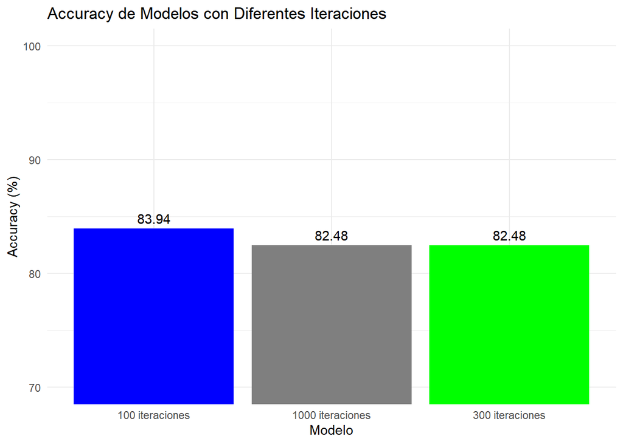

```r
# Extraer Accuracy de las matrices de confusión
accuracy_values <- c(
  matrizConfusion.nnet.100$overall["Accuracy"] * 100,
  matrizConfusion.nnet.300$overall["Accuracy"] * 100,
  matrizConfusion.nnet.1000$overall["Accuracy"] * 100
)

# Crear un data frame con los resultados
resultados <- data.frame(
  Modelo = c("100 iteraciones", "300 iteraciones", "1000 iteraciones"),
  Accuracy = accuracy_values
)


# Crear el histograma
ggplot(resultados, aes(x = Modelo, y = Accuracy, fill = Modelo)) +
  geom_bar(stat = "identity", position = "dodge") +
  geom_text(aes(label = round(Accuracy, 2)), vjust = -0.5) + # Agregar etiquetas con valores
  labs(
    title = "Accuracy de Modelos con Diferentes Iteraciones",
    x = "Modelo",
    y = "Accuracy (%)"
  ) +
  scale_fill_manual(values = c("100 iteraciones" = "blue", "300 iteraciones" = "green", "500 iteraciones" = "orange")) +
  theme_minimal() +
  theme(legend.position = "none") +
  coord_cartesian(ylim = c(70, 100))
```

Por lo tanto concluimos que el que mejor resultados da es con 100 iteraciones.

### 6.5.5 Reentrenamiento y testeo

Para evitar picking vamos a reentrenar nuestro mejor modelo anterior con hiperparametros fijos para tener un valor mas real de las predicciones, por lo que entrenaremos el modelo de 100 iteraciones con un valor de size de 4 y de decay de 0.5.

```r
nnet.Grid.final <- expand.grid(
  size = c(4),
  decay = c(0.5)
)

set.seed(123)
nnet.train.100.final <- train(
  x = credit.Datos.nnet.Train[varsPredictoras],
  y = credit.Datos.nnet.Train[[varObjetivo]],
  method = "nnet",
  metric = "ROC",
  trControl = nnet.trainControl,
  tuneGrid = nnet.Grid.final,
  trace = FALSE,
  maxit = 100
)
```

Vamos con la predicción en nuestro conjunto test.

```r
prediccion.nnet.100.final <- predict(nnet.train.100.final, newdata = credit.Datos.nnet.Test[varsPredictoras])

matrizConfusion.nnet.100.final <- confusionMatrix(
  data = prediccion.nnet.100.final,
  reference = credit.Datos.Test[[varObjetivo]],
  positive = "aprobada" # Cambia esto por la clase objetivo positiva
)
```

Comparamos ahora los resultados.

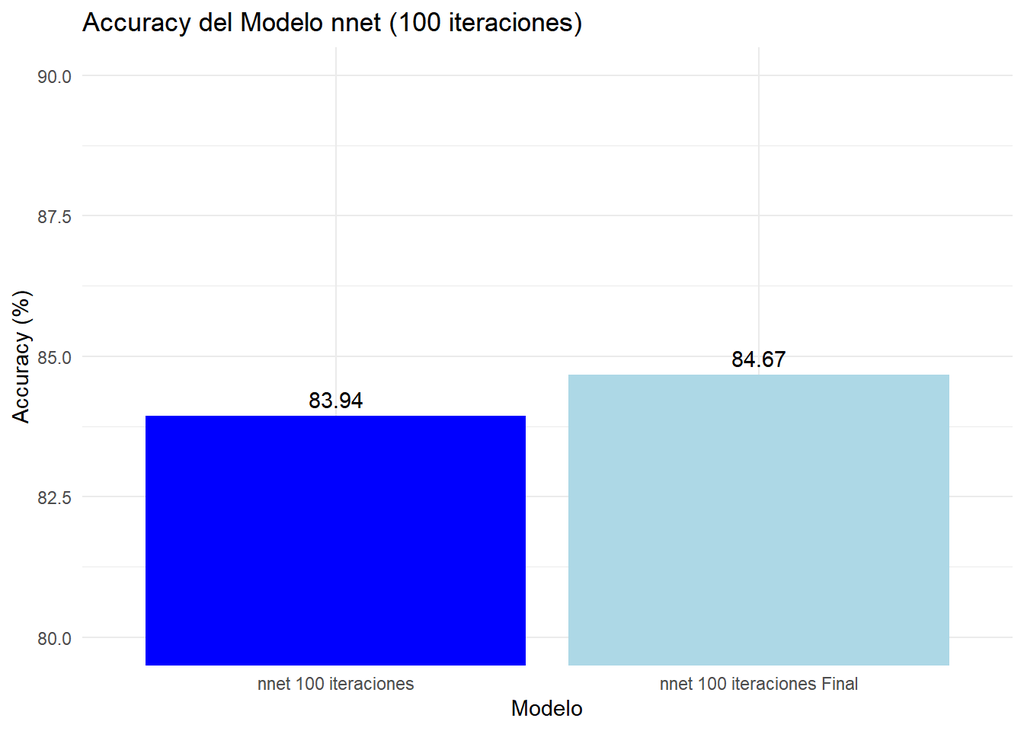

```r
# Extraer Accuracy de las matrices de confusión
accuracy_values <- c(
  matrizConfusion.nnet.100$overall["Accuracy"] * 100,
  matrizConfusion.nnet.100.final$overall["Accuracy"] * 100
)

# Crear un data frame con los resultados
resultados <- data.frame(
  Modelo = c("nnet 100 iteraciones", "nnet 100 iteraciones Final"),
  Accuracy = accuracy_values
)

# Crear el histograma
ggplot(resultados, aes(x = Modelo, y = Accuracy, fill = Modelo)) +
  geom_bar(stat = "identity", position = "dodge") +
  geom_text(aes(label = round(Accuracy, 2)), vjust = -0.5) + # Agregar etiquetas con valores
  labs(
    title = "Accuracy del Modelo nnet (100 iteraciones)",
    x = "Modelo",
    y = "Accuracy (%)"
  ) +
  scale_fill_manual(values = c("nnet 100 iteraciones" = "blue", "nnet 100 iteraciones Final" = "lightblue")) +
  theme_minimal() +
  coord_cartesian(ylim = c(80, 90)) +
  theme(legend.position = "none") # Ocultar leyenda, ya que el eje X describe los modelos
```

Con los hiperparametros fijos nos da incluso mejores resultados por lo que este será nuestro modelo final.

### 6.5.6 Postprocesado de datos

Antes de elegir definitivamente el modelo vamos a hacer un postprocesado de los datos y ver que variables se usan mas.

```r
varImp(nnet.train.100.final)
```

```
## nnet variable importance
##
##   only 20 most important variables shown (out of 38)
##
##                        Overall
## V9.t                    100.00
## V6.x                     62.92
## composicionPoblacion.p   59.37
## V7.ff                    39.08
## V6.cc                    37.94
## V7.h                     35.98
## Empleado.t               32.63
## V15                      29.11
## Solvencia                27.41
## V5.gg                    27.14
## Edad                     27.01
## V6.q                     26.88
## V14                      25.41
## V6.c                     24.68
## V12.t                    22.85
## EstadoCivil.u            22.09
## V6.k                     21.80
## V6.i                     21.40
## V7.n                     19.61
## EstadoCivil.y            19.21
```

Vemos que no hay ninguna variable que se use “poco” por lo qu eno sería necesario hacer un postprocesado de los datos.

### 6.5.7 Conclusión

El modelo final de redes neuronales nos ha dado un porcentaje de acierto 84,67%, esta por debajo de otros modelos pero la ventaja que he detectado en este modelo es que a pesar de tener un preprocesado de datos mas complejo de random forest, funciona muy bien con iteraciones bajas lo que mejora mucho el tiempo de computo.

Nuestro modelo final es por tanto:

```r
print(nnet.train.100.final)
```

```
## Neural Network
##
## 553 samples
##  38 predictor
##   2 classes: 'rechazada', 'aprobada'
##
## No pre-processing
## Resampling: Cross-Validated (10 fold, repeated 3 times)
## Summary of sample sizes: 498, 497, 498, 499, 497, 498, ...
## Resampling results:
##
##   ROC        Sens       Spec
##   0.9299645  0.8915054  0.8445
##
## Tuning parameter 'size' was held constant at a value of 4
## Tuning
##  parameter 'decay' was held constant at a value of 0.5
```

### 6.5.8 Bibliografía Redes Neuronales

Aprendizaje Computacional. (s.f.). Análisis de datos y machine learning con R (caret). Versión 0.105 (pre-release)

Amat Rodrigo, J. (n.d.). Machine Learning con R y caret. Recuperado de https://cienciadedatos.net/documentos/41_machine_learning_con_r_y_caret

Fernández, A. (n.d.). Machine Learning en R con caret. Recuperado de https://anderfernandez.com/blog/machine-learning-caret-r/

Charte, F. (2016). Redes neuronales con R. Recuperado de https://fcharte.com/tutoriales/20160203-R-RedesNeuronales/

Amat Rodrigo, J. (n.d.). Redes neuronales con R. Recuperado de https://cienciadedatos.net/documentos/68-redes-neuronales-r

ISGlobal BRGE. (n.d.). La librería caret. Recuperado de https://isglobal-brge.github.io/curso_machine_learning/caret.html

# 7 Conclusiónes finales

En este trabajo, hemos evaluado múltiples modelos de aprendizaje automático, considerando tanto su rendimiento como los requisitos de preprocesado. Cada modelo ha mostrado fortalezas y debilidades, lo que nos permite reflexionar sobre su idoneidad según las necesidades específicas:

KNN obtuvo el mayor porcentaje de acierto (87.59%) tras aplicar normalización, transformación de variables categóricas y eliminación de variables con varianza nula. Sin embargo, su rendimiento depende de un preprocesado relativamente extenso.

GBM logró un acierto del 86.13%, empleando configuraciones automáticas de preprocesado y optimización de parámetros. Aunque no fue el modelo con mayor precisión, mostró una gran estabilidad y flexibilidad.

SVM, con un porcentaje de acierto del 85.4%, benefició significativamente de un preprocesado avanzado, incluyendo PCA y eliminación de variables con baja varianza, pero mostró menor rendimiento en comparación con modelos menos exigentes en esta etapa.

Redes Neuronales (nnet), aunque ligeramente por debajo en precisión (84.67%), ofrecieron una ventaja en términos de tiempo de cómputo, funcionando eficazmente con iteraciones bajas pese a requerir un preprocesado más complejo.

Conclusión General: El modelo Random Forest se posiciona como el más equilibrado al ofrecer un alto porcentaje de acierto con requisitos mínimos de preprocesado, siendo ideal para implementaciones rápidas y prácticas. Sin embargo, en situaciones donde se puede invertir más tiempo en preprocesado, KNN sería una excelente alternativa por su rendimiento superior. Esta experiencia resalta la importancia de adaptar los modelos y su configuración a las necesidades y restricciones del problema.